# Part B identification sweep (`idsweep`)

Detection, subgroup size and classification: three engines × six selection criteria × 18 cells, 500 replicates each, MR off (TASK_idsweep_2026-09-12)

Author

Larry León

Published

September 13, 2026

# 1 Reading this document

- **What it measures: identification and classification only.** MR is off on every run (`FS_S7_MR=FALSE`, `_nomr` in every stem). There is no MR, no field construction, no coverage, no bias and no bound here. The MR-derived columns are NA by design and are not read.
- **A self-contained campaign.** Every number below comes from the `idsweep` bundles (`results/*_nomr_idsweep_res_1_500.rds`), one tag and one knob set. No earlier bundle is used as data.
- **Design.** GBSG-based survival DGM, one template (`sim_fs_maxeffCons_fb_mr_field_m1_template.qmd`). 18 cells: prevalence 12.4% (`FS_S7_Z1Q` unset) or 31% (`FS_S7_Z1Q=0.60`) × HR 1.50, 1.75, 1.00 × n 500, 1000, 1500. 500 replicates per run, sim_id 1–500, seeds 8316951 + sim_id, so every run within a cell sees the same trials.
- **Sixteen runs per cell.**
  - Consistency: `effMaxSG` (ε 0.20), `effMinSG` (ε 0.20), `maxeffCons`, `maxeff`, `maxSG`, `minSG`.
  - DINA and GRF: `effMaxSG` (ε 0.20), `effMinSG` (ε 0.20), `maxSG`, `minSG`, `eff`.
  - **On DINA and GRF, `eff` stands for `eff` = `maxeff` = `maxeffCons`**: all three resolve to the plain effect argmax on those engines. It was run once, passed as `maxeffCons`.
  - ε is set only for the two band criteria. GRF carries the rule as `frontier_rule` under `grf_selection = "frontier"`, with ε 0.20 set explicitly.
- **Column definitions.**
  - **Rate:** detected replicates / 500, with a Wilson 95% interval. It is a **detection rate** at HR 1.50 and 1.75, and a **selection rate** at HR 1.00.
  - **Sens / spec / PPV / NPV:** replicate means, over detected replicates, of each replicate’s subject-level rates against the planted region. They carry no interval: each is a mean of per-replicate proportions, not a rate over replicates.
  - **Mean |Ĥ|, mean |H|:** mean `n_sel` and mean `n_true` over detected replicates; the ratio is of the two means.
  - **`admitted_n`:** GRF only; median [min, max] over replicates. It does not depend on the criterion.
  - **Realized prevalence:** mean `n_true / n` over all 500 replicates.
- **The HR 1.00 cells are not a global null.** The planted region carries HR 1.00 and is **differentially null against a benefiting complement**. It clears the sub-null log(0.90) floor (`hr_threshold = 0.90` in the template), so returning it is an admissible selection. The rate there is a selection rate and nothing more; it is not an error rate.
- **Descriptive only.** There is no acceptance criterion and no recommendation. Comparisons across engines carry the usual confound: identifier, family construction and detection set.

# 2 Grid status

One row per cell in run order. A cell with fewer than 16 runs present was not completed (deferred from the tail); absent cells have no per-cell section. Realized prevalence is the same on every run of a cell because the runs share draws. The planted marginal Cox HR is the DGM’s super-population value, attenuated by non-collapsibility; it is context for the cell, not a target, and nothing in this document is scored against it.

| Cell | Prevalence | HR | n | Runs present | MR off (all runs) | Replicates | Non-detections | Other statuses | Realized prevalence | Super-population | Planted marginal Cox HR, H / Hc |
| --- | --- | --- | --- | --- | --- | --- | --- | --- | --- | --- | --- |
| p124_h150_n500 | 12.4% | 1.50 | 500 | 16 / 16 | TRUE | 8000 | 560 | 0 | 0.1233 | 0.1242 | 1.509 / 0.657 |
| p124_h150_n1000 | 12.4% | 1.50 | 1000 | 16 / 16 | TRUE | 8000 | 490 | 0 | 0.1238 | 0.1242 | 1.509 / 0.657 |
| p124_h150_n1500 | 12.4% | 1.50 | 1500 | 16 / 16 | TRUE | 8000 | 550 | 0 | 0.1238 | 0.1242 | 1.509 / 0.657 |
| p31_h150_n500 | 31% | 1.50 | 500 | 16 / 16 | TRUE | 8000 | 0 | 0 | 0.3070 | 0.3065 | 1.499 / 0.721 |
| p31_h150_n1000 | 31% | 1.50 | 1000 | 16 / 16 | TRUE | 8000 | 0 | 0 | 0.3070 | 0.3065 | 1.499 / 0.721 |
| p31_h150_n1500 | 31% | 1.50 | 1500 | 16 / 16 | TRUE | 8000 | 0 | 0 | 0.3069 | 0.3065 | 1.499 / 0.721 |
| p124_h175_n500 | 12.4% | 1.75 | 500 | 16 / 16 | TRUE | 8000 | 370 | 0 | 0.1233 | 0.1242 | 1.769 / 0.657 |
| p124_h175_n1000 | 12.4% | 1.75 | 1000 | 16 / 16 | TRUE | 8000 | 255 | 0 | 0.1238 | 0.1242 | 1.769 / 0.657 |
| p124_h175_n1500 | 12.4% | 1.75 | 1500 | 16 / 16 | TRUE | 8000 | 260 | 0 | 0.1238 | 0.1242 | 1.769 / 0.657 |
| p31_h175_n500 | 31% | 1.75 | 500 | 16 / 16 | TRUE | 8000 | 0 | 0 | 0.3070 | 0.3065 | 1.746 / 0.721 |
| p31_h175_n1000 | 31% | 1.75 | 1000 | 16 / 16 | TRUE | 8000 | 0 | 0 | 0.3070 | 0.3065 | 1.746 / 0.721 |
| p31_h175_n1500 | 31% | 1.75 | 1500 | 16 / 16 | TRUE | 8000 | 0 | 0 | 0.3069 | 0.3065 | 1.746 / 0.721 |
| p124_h100_n500 | 12.4% | 1.00 | 500 | 16 / 16 | TRUE | 8000 | 1655 | 0 | 0.1233 | 0.1242 | 1.000 / 0.657 |
| p124_h100_n1000 | 12.4% | 1.00 | 1000 | 16 / 16 | TRUE | 8000 | 2080 | 0 | 0.1238 | 0.1242 | 1.000 / 0.657 |
| p124_h100_n1500 | 12.4% | 1.00 | 1500 | 16 / 16 | TRUE | 8000 | 2930 | 0 | 0.1238 | 0.1242 | 1.000 / 0.657 |
| p31_h100_n500 | 31% | 1.00 | 500 | 16 / 16 | TRUE | 8000 | 390 | 0 | 0.3070 | 0.3065 | 1.000 / 0.721 |
| p31_h100_n1000 | 31% | 1.00 | 1000 | 16 / 16 | TRUE | 8000 | 330 | 0 | 0.3070 | 0.3065 | 1.000 / 0.721 |
| p31_h100_n1500 | 31% | 1.00 | 1500 | 16 / 16 | TRUE | 8000 | 365 | 0 | 0.3069 | 0.3065 | 1.000 / 0.721 |

# 3 Per cell: the OC table

## 3.1 12.4%, HR 1.50, n 500

12.4%, HR 1.50, n 500, 500 replicates, MR off. On DINA and GRF, eff stands for eff = maxeff = maxeffCons (run once). eps is set for effMaxSG / effMinSG only. Sens, spec, PPV and NPV are replicate means over detected replicates (no interval: means of per-replicate proportions); mean |Ĥ| and |H| are over detected replicates, with the ratio of the two means. admitted_n is GRF only. Realized prevalence is over all 500 replicates (super-population 0.1242).

| Engine | sg_focus | eps | Detection rate [Wilson 95%] (k/n) | Sens | Spec | PPV | NPV | Mean \|Ĥ\| | Mean \|H\| | \|Ĥ\| / \|H\| | admitted_n median [range] | Realized prevalence |
| --- | --- | --- | --- | --- | --- | --- | --- | --- | --- | --- | --- | --- |
| consistency | effMaxSG | 0.20 | 0.908 [0.879, 0.930] (454/500) | 0.618 | 0.856 | 0.417 | 0.940 | 101.9 | 61.9 | 1.646 | – | 0.1233 |
| consistency | effMinSG | 0.20 | 0.908 [0.879, 0.930] (454/500) | 0.571 | 0.928 | 0.538 | 0.939 | 67.2 | 61.9 | 1.085 | – | 0.1233 |
| consistency | maxeffCons | not set | 0.908 [0.879, 0.930] (454/500) | 0.572 | 0.912 | 0.503 | 0.938 | 74.3 | 61.9 | 1.200 | – | 0.1233 |
| consistency | maxeff | not set | 1.000 [0.992, 1.000] (500/500) | 0.541 | 0.909 | 0.476 | 0.934 | 73.4 | 61.6 | 1.191 | – | 0.1233 |
| consistency | maxSG | not set | 0.908 [0.879, 0.930] (454/500) | 0.742 | 0.702 | 0.303 | 0.953 | 176.9 | 61.9 | 2.859 | – | 0.1233 |
| consistency | minSG | not set | 0.908 [0.879, 0.930] (454/500) | 0.521 | 0.923 | 0.496 | 0.931 | 66.0 | 61.9 | 1.067 | – | 0.1233 |
| dina | effMaxSG | 0.20 | 0.872 [0.840, 0.898] (436/500) | 0.514 | 0.856 | 0.346 | 0.927 | 95.4 | 61.7 | 1.546 | – | 0.1233 |
| dina | effMinSG | 0.20 | 0.872 [0.840, 0.898] (436/500) | 0.401 | 0.913 | 0.393 | 0.916 | 63.1 | 61.7 | 1.023 | – | 0.1233 |
| dina | eff (= maxeff = maxeffCons) | not set | 0.872 [0.840, 0.898] (436/500) | 0.435 | 0.901 | 0.390 | 0.919 | 70.4 | 61.7 | 1.141 | – | 0.1233 |
| dina | maxSG | not set | 0.872 [0.840, 0.898] (436/500) | 0.719 | 0.602 | 0.223 | 0.946 | 219.1 | 61.7 | 3.552 | – | 0.1233 |
| dina | minSG | not set | 0.872 [0.840, 0.898] (436/500) | 0.342 | 0.909 | 0.345 | 0.908 | 61.2 | 61.7 | 0.992 | – | 0.1233 |
| grf | effMaxSG | 0.20 | 0.996 [0.986, 0.999] (498/500) | 0.529 | 0.839 | 0.330 | 0.928 | 103.6 | 61.6 | 1.681 | 110 [3, 600] | 0.1233 |
| grf | effMinSG | 0.20 | 0.996 [0.986, 0.999] (498/500) | 0.335 | 0.902 | 0.324 | 0.906 | 63.7 | 61.6 | 1.033 | 110 [3, 600] | 0.1233 |
| grf | eff (= maxeff = maxeffCons) | not set | 0.996 [0.986, 0.999] (498/500) | 0.401 | 0.892 | 0.342 | 0.914 | 72.3 | 61.6 | 1.173 | 110 [3, 600] | 0.1233 |
| grf | maxSG | not set | 0.996 [0.986, 0.999] (498/500) | 0.753 | 0.500 | 0.189 | 0.937 | 266.0 | 61.6 | 4.317 | 110 [3, 600] | 0.1233 |
| grf | minSG | not set | 0.996 [0.986, 0.999] (498/500) | 0.270 | 0.901 | 0.278 | 0.898 | 60.5 | 61.6 | 0.981 | 110 [3, 600] | 0.1233 |

**Undefined rates.** A classification rate is undefined when its denominator is zero: NPV when the selection is the whole trial (no predicted negatives). The mean in the table is over the remaining detected replicates. dina maxSG: NPV undefined on 8, PPV 0, sensitivity 0, specificity 0 detected replicate(s); selection = whole trial on 8.

## 3.2 12.4%, HR 1.50, n 1000

12.4%, HR 1.50, n 1000, 500 replicates, MR off. On DINA and GRF, eff stands for eff = maxeff = maxeffCons (run once). eps is set for effMaxSG / effMinSG only. Sens, spec, PPV and NPV are replicate means over detected replicates (no interval: means of per-replicate proportions); mean |Ĥ| and |H| are over detected replicates, with the ratio of the two means. admitted_n is GRF only. Realized prevalence is over all 500 replicates (super-population 0.1242).

| Engine | sg_focus | eps | Detection rate [Wilson 95%] (k/n) | Sens | Spec | PPV | NPV | Mean \|Ĥ\| | Mean \|H\| | \|Ĥ\| / \|H\| | admitted_n median [range] | Realized prevalence |
| --- | --- | --- | --- | --- | --- | --- | --- | --- | --- | --- | --- | --- |
| consistency | effMaxSG | 0.20 | 0.966 [0.946, 0.979] (483/500) | 0.775 | 0.906 | 0.576 | 0.966 | 178.9 | 124.0 | 1.443 | – | 0.1238 |
| consistency | effMinSG | 0.20 | 0.966 [0.946, 0.979] (483/500) | 0.555 | 0.953 | 0.626 | 0.938 | 109.5 | 124.0 | 0.883 | – | 0.1238 |
| consistency | maxeffCons | not set | 0.966 [0.946, 0.979] (483/500) | 0.692 | 0.958 | 0.701 | 0.957 | 122.8 | 124.0 | 0.991 | – | 0.1238 |
| consistency | maxeff | not set | 1.000 [0.992, 1.000] (500/500) | 0.670 | 0.956 | 0.680 | 0.954 | 122.2 | 123.8 | 0.987 | – | 0.1238 |
| consistency | maxSG | not set | 0.966 [0.946, 0.979] (483/500) | 0.856 | 0.729 | 0.353 | 0.974 | 344.1 | 124.0 | 2.776 | – | 0.1238 |
| consistency | minSG | not set | 0.966 [0.946, 0.979] (483/500) | 0.501 | 0.949 | 0.579 | 0.931 | 106.9 | 124.0 | 0.862 | – | 0.1238 |
| dina | effMaxSG | 0.20 | 0.838 [0.803, 0.868] (419/500) | 0.668 | 0.898 | 0.513 | 0.951 | 172.8 | 124.2 | 1.392 | – | 0.1238 |
| dina | effMinSG | 0.20 | 0.838 [0.803, 0.868] (419/500) | 0.481 | 0.948 | 0.568 | 0.928 | 105.6 | 124.2 | 0.851 | – | 0.1238 |
| dina | eff (= maxeff = maxeffCons) | not set | 0.838 [0.803, 0.868] (419/500) | 0.570 | 0.946 | 0.607 | 0.940 | 118.0 | 124.2 | 0.950 | – | 0.1238 |
| dina | maxSG | not set | 0.838 [0.803, 0.868] (419/500) | 0.788 | 0.686 | 0.292 | 0.963 | 373.0 | 124.2 | 3.005 | – | 0.1238 |
| dina | minSG | not set | 0.838 [0.803, 0.868] (419/500) | 0.359 | 0.934 | 0.435 | 0.911 | 102.7 | 124.2 | 0.827 | – | 0.1238 |
| grf | effMaxSG | 0.20 | 1.000 [0.992, 1.000] (500/500) | 0.633 | 0.885 | 0.479 | 0.945 | 179.0 | 123.8 | 1.446 | 92.5 [3, 362] | 0.1238 |
| grf | effMinSG | 0.20 | 1.000 [0.992, 1.000] (500/500) | 0.504 | 0.952 | 0.597 | 0.931 | 104.6 | 123.8 | 0.845 | 92.5 [3, 362] | 0.1238 |
| grf | eff (= maxeff = maxeffCons) | not set | 1.000 [0.992, 1.000] (500/500) | 0.560 | 0.947 | 0.611 | 0.938 | 115.8 | 123.8 | 0.935 | 92.5 [3, 362] | 0.1238 |
| grf | maxSG | not set | 1.000 [0.992, 1.000] (500/500) | 0.838 | 0.602 | 0.248 | 0.964 | 452.8 | 123.8 | 3.657 | 92.5 [3, 362] | 0.1238 |
| grf | minSG | not set | 1.000 [0.992, 1.000] (500/500) | 0.329 | 0.931 | 0.399 | 0.907 | 101.2 | 123.8 | 0.817 | 92.5 [3, 362] | 0.1238 |

## 3.3 12.4%, HR 1.50, n 1500

12.4%, HR 1.50, n 1500, 500 replicates, MR off. On DINA and GRF, eff stands for eff = maxeff = maxeffCons (run once). eps is set for effMaxSG / effMinSG only. Sens, spec, PPV and NPV are replicate means over detected replicates (no interval: means of per-replicate proportions); mean |Ĥ| and |H| are over detected replicates, with the ratio of the two means. admitted_n is GRF only. Realized prevalence is over all 500 replicates (super-population 0.1242).

| Engine | sg_focus | eps | Detection rate [Wilson 95%] (k/n) | Sens | Spec | PPV | NPV | Mean \|Ĥ\| | Mean \|H\| | \|Ĥ\| / \|H\| | admitted_n median [range] | Realized prevalence |
| --- | --- | --- | --- | --- | --- | --- | --- | --- | --- | --- | --- | --- |
| consistency | effMaxSG | 0.20 | 0.988 [0.974, 0.994] (494/500) | 0.882 | 0.918 | 0.643 | 0.982 | 271.6 | 185.9 | 1.461 | – | 0.1238 |
| consistency | effMinSG | 0.20 | 0.988 [0.974, 0.994] (494/500) | 0.621 | 0.963 | 0.700 | 0.947 | 164.0 | 185.9 | 0.882 | – | 0.1238 |
| consistency | maxeffCons | not set | 0.988 [0.974, 0.994] (494/500) | 0.817 | 0.975 | 0.818 | 0.974 | 185.2 | 185.9 | 0.996 | – | 0.1238 |
| consistency | maxeff | not set | 1.000 [0.992, 1.000] (500/500) | 0.814 | 0.975 | 0.816 | 0.974 | 184.5 | 185.8 | 0.993 | – | 0.1238 |
| consistency | maxSG | not set | 0.988 [0.974, 0.994] (494/500) | 0.921 | 0.745 | 0.381 | 0.986 | 505.9 | 185.9 | 2.721 | – | 0.1238 |
| consistency | minSG | not set | 0.988 [0.974, 0.994] (494/500) | 0.527 | 0.954 | 0.615 | 0.934 | 158.7 | 185.9 | 0.854 | – | 0.1238 |
| dina | effMaxSG | 0.20 | 0.794 [0.756, 0.827] (397/500) | 0.721 | 0.902 | 0.546 | 0.958 | 263.0 | 186.3 | 1.412 | – | 0.1238 |
| dina | effMinSG | 0.20 | 0.794 [0.756, 0.827] (397/500) | 0.526 | 0.954 | 0.620 | 0.934 | 158.7 | 186.3 | 0.852 | – | 0.1238 |
| dina | eff (= maxeff = maxeffCons) | not set | 0.794 [0.756, 0.827] (397/500) | 0.632 | 0.956 | 0.678 | 0.948 | 175.6 | 186.3 | 0.942 | – | 0.1238 |
| dina | maxSG | not set | 0.794 [0.756, 0.827] (397/500) | 0.785 | 0.732 | 0.316 | 0.965 | 498.5 | 186.3 | 2.676 | – | 0.1238 |
| dina | minSG | not set | 0.794 [0.756, 0.827] (397/500) | 0.401 | 0.939 | 0.483 | 0.917 | 154.7 | 186.3 | 0.830 | – | 0.1238 |
| grf | effMaxSG | 0.20 | 0.998 [0.989, 1.000] (499/500) | 0.749 | 0.899 | 0.564 | 0.963 | 271.5 | 185.8 | 1.461 | 76 [5, 300] | 0.1238 |
| grf | effMinSG | 0.20 | 0.998 [0.989, 1.000] (499/500) | 0.582 | 0.963 | 0.692 | 0.942 | 156.1 | 185.8 | 0.840 | 76 [5, 300] | 0.1238 |
| grf | eff (= maxeff = maxeffCons) | not set | 0.998 [0.989, 1.000] (499/500) | 0.644 | 0.960 | 0.713 | 0.950 | 172.2 | 185.8 | 0.927 | 76 [5, 300] | 0.1238 |
| grf | maxSG | not set | 0.998 [0.989, 1.000] (499/500) | 0.849 | 0.657 | 0.276 | 0.970 | 608.9 | 185.8 | 3.277 | 76 [5, 300] | 0.1238 |
| grf | minSG | not set | 0.998 [0.989, 1.000] (499/500) | 0.376 | 0.937 | 0.457 | 0.914 | 151.9 | 185.8 | 0.818 | 76 [5, 300] | 0.1238 |

## 3.4 31%, HR 1.50, n 500

31%, HR 1.50, n 500, 500 replicates, MR off. On DINA and GRF, eff stands for eff = maxeff = maxeffCons (run once). eps is set for effMaxSG / effMinSG only. Sens, spec, PPV and NPV are replicate means over detected replicates (no interval: means of per-replicate proportions); mean |Ĥ| and |H| are over detected replicates, with the ratio of the two means. admitted_n is GRF only. Realized prevalence is over all 500 replicates (super-population 0.3065).

| Engine | sg_focus | eps | Detection rate [Wilson 95%] (k/n) | Sens | Spec | PPV | NPV | Mean \|Ĥ\| | Mean \|H\| | \|Ĥ\| / \|H\| | admitted_n median [range] | Realized prevalence |
| --- | --- | --- | --- | --- | --- | --- | --- | --- | --- | --- | --- | --- |
| consistency | effMaxSG | 0.20 | 1.000 [0.992, 1.000] (500/500) | 0.584 | 0.891 | 0.704 | 0.834 | 127.5 | 153.5 | 0.830 | – | 0.3070 |
| consistency | effMinSG | 0.20 | 1.000 [0.992, 1.000] (500/500) | 0.285 | 0.935 | 0.659 | 0.747 | 66.1 | 153.5 | 0.430 | – | 0.3070 |
| consistency | maxeffCons | not set | 1.000 [0.992, 1.000] (500/500) | 0.357 | 0.928 | 0.685 | 0.766 | 79.6 | 153.5 | 0.518 | – | 0.3070 |
| consistency | maxeff | not set | 1.000 [0.992, 1.000] (500/500) | 0.356 | 0.929 | 0.686 | 0.766 | 79.3 | 153.5 | 0.516 | – | 0.3070 |
| consistency | maxSG | not set | 1.000 [0.992, 1.000] (500/500) | 0.914 | 0.351 | 0.407 | 0.913 | 365.0 | 153.5 | 2.377 | – | 0.3070 |
| consistency | minSG | not set | 1.000 [0.992, 1.000] (500/500) | 0.245 | 0.928 | 0.600 | 0.735 | 62.5 | 153.5 | 0.407 | – | 0.3070 |
| dina | effMaxSG | 0.20 | 1.000 [0.992, 1.000] (500/500) | 0.519 | 0.909 | 0.697 | 0.816 | 111.2 | 153.5 | 0.724 | – | 0.3070 |
| dina | effMinSG | 0.20 | 1.000 [0.992, 1.000] (500/500) | 0.257 | 0.933 | 0.627 | 0.739 | 62.7 | 153.5 | 0.409 | – | 0.3070 |
| dina | eff (= maxeff = maxeffCons) | not set | 1.000 [0.992, 1.000] (500/500) | 0.316 | 0.931 | 0.666 | 0.755 | 72.2 | 153.5 | 0.471 | – | 0.3070 |
| dina | maxSG | not set | 1.000 [0.992, 1.000] (500/500) | 0.951 | 0.202 | 0.362 | 0.903 | 422.2 | 153.5 | 2.750 | – | 0.3070 |
| dina | minSG | not set | 1.000 [0.992, 1.000] (500/500) | 0.223 | 0.925 | 0.568 | 0.729 | 60.2 | 153.5 | 0.392 | – | 0.3070 |
| grf | effMaxSG | 0.20 | 1.000 [0.992, 1.000] (500/500) | 0.534 | 0.904 | 0.697 | 0.820 | 115.2 | 153.5 | 0.750 | 369 [32, 752] | 0.3070 |
| grf | effMinSG | 0.20 | 1.000 [0.992, 1.000] (500/500) | 0.246 | 0.922 | 0.578 | 0.734 | 64.8 | 153.5 | 0.422 | 369 [32, 752] | 0.3070 |
| grf | eff (= maxeff = maxeffCons) | not set | 1.000 [0.992, 1.000] (500/500) | 0.322 | 0.922 | 0.635 | 0.755 | 76.1 | 153.5 | 0.495 | 369 [32, 752] | 0.3070 |
| grf | maxSG | not set | 1.000 [0.992, 1.000] (500/500) | 0.934 | 0.192 | 0.345 | 0.847 | 423.2 | 153.5 | 2.757 | 369 [32, 752] | 0.3070 |
| grf | minSG | not set | 1.000 [0.992, 1.000] (500/500) | 0.162 | 0.898 | 0.414 | 0.708 | 60.1 | 153.5 | 0.392 | 369 [32, 752] | 0.3070 |

**Undefined rates.** A classification rate is undefined when its denominator is zero: NPV when the selection is the whole trial (no predicted negatives). The mean in the table is over the remaining detected replicates. dina maxSG: NPV undefined on 160, PPV 0, sensitivity 0, specificity 0 detected replicate(s); selection = whole trial on 160.

## 3.5 31%, HR 1.50, n 1000

31%, HR 1.50, n 1000, 500 replicates, MR off. On DINA and GRF, eff stands for eff = maxeff = maxeffCons (run once). eps is set for effMaxSG / effMinSG only. Sens, spec, PPV and NPV are replicate means over detected replicates (no interval: means of per-replicate proportions); mean |Ĥ| and |H| are over detected replicates, with the ratio of the two means. admitted_n is GRF only. Realized prevalence is over all 500 replicates (super-population 0.3065).

| Engine | sg_focus | eps | Detection rate [Wilson 95%] (k/n) | Sens | Spec | PPV | NPV | Mean \|Ĥ\| | Mean \|H\| | \|Ĥ\| / \|H\| | admitted_n median [range] | Realized prevalence |
| --- | --- | --- | --- | --- | --- | --- | --- | --- | --- | --- | --- | --- |
| consistency | effMaxSG | 0.20 | 1.000 [0.992, 1.000] (500/500) | 0.720 | 0.926 | 0.807 | 0.890 | 272.0 | 307.0 | 0.886 | – | 0.3070 |
| consistency | effMinSG | 0.20 | 1.000 [0.992, 1.000] (500/500) | 0.254 | 0.956 | 0.713 | 0.743 | 108.5 | 307.0 | 0.354 | – | 0.3070 |
| consistency | maxeffCons | not set | 1.000 [0.992, 1.000] (500/500) | 0.348 | 0.956 | 0.754 | 0.770 | 137.5 | 307.0 | 0.448 | – | 0.3070 |
| consistency | maxeff | not set | 1.000 [0.992, 1.000] (500/500) | 0.347 | 0.955 | 0.752 | 0.769 | 137.4 | 307.0 | 0.448 | – | 0.3070 |
| consistency | maxSG | not set | 1.000 [0.992, 1.000] (500/500) | 0.966 | 0.250 | 0.372 | 0.958 | 816.1 | 307.0 | 2.658 | – | 0.3070 |
| consistency | minSG | not set | 1.000 [0.992, 1.000] (500/500) | 0.203 | 0.942 | 0.606 | 0.727 | 102.7 | 307.0 | 0.335 | – | 0.3070 |
| dina | effMaxSG | 0.20 | 1.000 [0.992, 1.000] (500/500) | 0.634 | 0.931 | 0.793 | 0.859 | 242.5 | 307.0 | 0.790 | – | 0.3070 |
| dina | effMinSG | 0.20 | 1.000 [0.992, 1.000] (500/500) | 0.241 | 0.957 | 0.710 | 0.740 | 103.9 | 307.0 | 0.339 | – | 0.3070 |
| dina | eff (= maxeff = maxeffCons) | not set | 1.000 [0.992, 1.000] (500/500) | 0.305 | 0.957 | 0.748 | 0.757 | 123.5 | 307.0 | 0.402 | – | 0.3070 |
| dina | maxSG | not set | 1.000 [0.992, 1.000] (500/500) | 0.981 | 0.157 | 0.351 | 0.927 | 884.9 | 307.0 | 2.882 | – | 0.3070 |
| dina | minSG | not set | 1.000 [0.992, 1.000] (500/500) | 0.193 | 0.941 | 0.591 | 0.725 | 100.1 | 307.0 | 0.326 | – | 0.3070 |
| grf | effMaxSG | 0.20 | 1.000 [0.992, 1.000] (500/500) | 0.676 | 0.932 | 0.806 | 0.876 | 254.9 | 307.0 | 0.830 | 408.5 [81, 751] | 0.3070 |
| grf | effMinSG | 0.20 | 1.000 [0.992, 1.000] (500/500) | 0.251 | 0.957 | 0.721 | 0.743 | 106.5 | 307.0 | 0.347 | 408.5 [81, 751] | 0.3070 |
| grf | eff (= maxeff = maxeffCons) | not set | 1.000 [0.992, 1.000] (500/500) | 0.328 | 0.954 | 0.745 | 0.764 | 132.4 | 307.0 | 0.431 | 408.5 [81, 751] | 0.3070 |
| grf | maxSG | not set | 1.000 [0.992, 1.000] (500/500) | 0.943 | 0.171 | 0.340 | 0.839 | 863.7 | 307.0 | 2.813 | 408.5 [81, 751] | 0.3070 |
| grf | minSG | not set | 1.000 [0.992, 1.000] (500/500) | 0.139 | 0.916 | 0.423 | 0.706 | 100.3 | 307.0 | 0.327 | 408.5 [81, 751] | 0.3070 |

**Undefined rates.** A classification rate is undefined when its denominator is zero: NPV when the selection is the whole trial (no predicted negatives). The mean in the table is over the remaining detected replicates. dina maxSG: NPV undefined on 164, PPV 0, sensitivity 0, specificity 0 detected replicate(s); selection = whole trial on 164.

## 3.6 31%, HR 1.50, n 1500

31%, HR 1.50, n 1500, 500 replicates, MR off. On DINA and GRF, eff stands for eff = maxeff = maxeffCons (run once). eps is set for effMaxSG / effMinSG only. Sens, spec, PPV and NPV are replicate means over detected replicates (no interval: means of per-replicate proportions); mean |Ĥ| and |H| are over detected replicates, with the ratio of the two means. admitted_n is GRF only. Realized prevalence is over all 500 replicates (super-population 0.3065).

| Engine | sg_focus | eps | Detection rate [Wilson 95%] (k/n) | Sens | Spec | PPV | NPV | Mean \|Ĥ\| | Mean \|H\| | \|Ĥ\| / \|H\| | admitted_n median [range] | Realized prevalence |
| --- | --- | --- | --- | --- | --- | --- | --- | --- | --- | --- | --- | --- |
| consistency | effMaxSG | 0.20 | 1.000 [0.992, 1.000] (500/500) | 0.841 | 0.924 | 0.834 | 0.937 | 466.5 | 460.3 | 1.013 | – | 0.3069 |
| consistency | effMinSG | 0.20 | 1.000 [0.992, 1.000] (500/500) | 0.262 | 0.962 | 0.748 | 0.746 | 160.1 | 460.3 | 0.348 | – | 0.3069 |
| consistency | maxeffCons | not set | 1.000 [0.992, 1.000] (500/500) | 0.395 | 0.969 | 0.831 | 0.786 | 214.1 | 460.3 | 0.465 | – | 0.3069 |
| consistency | maxeff | not set | 1.000 [0.992, 1.000] (500/500) | 0.395 | 0.969 | 0.831 | 0.786 | 214.1 | 460.3 | 0.465 | – | 0.3069 |
| consistency | maxSG | not set | 1.000 [0.992, 1.000] (500/500) | 0.979 | 0.207 | 0.358 | 0.968 | 1274.5 | 460.3 | 2.769 | – | 0.3069 |
| consistency | minSG | not set | 1.000 [0.992, 1.000] (500/500) | 0.199 | 0.941 | 0.598 | 0.726 | 152.8 | 460.3 | 0.332 | – | 0.3069 |
| dina | effMaxSG | 0.20 | 1.000 [0.992, 1.000] (500/500) | 0.783 | 0.938 | 0.847 | 0.916 | 424.9 | 460.3 | 0.923 | – | 0.3069 |
| dina | effMinSG | 0.20 | 1.000 [0.992, 1.000] (500/500) | 0.252 | 0.963 | 0.749 | 0.744 | 154.2 | 460.3 | 0.335 | – | 0.3069 |
| dina | eff (= maxeff = maxeffCons) | not set | 1.000 [0.992, 1.000] (500/500) | 0.347 | 0.968 | 0.818 | 0.771 | 192.7 | 460.3 | 0.419 | – | 0.3069 |
| dina | maxSG | not set | 1.000 [0.992, 1.000] (500/500) | 0.990 | 0.146 | 0.346 | 0.954 | 1343.5 | 460.3 | 2.919 | – | 0.3069 |
| dina | minSG | not set | 1.000 [0.992, 1.000] (500/500) | 0.196 | 0.942 | 0.600 | 0.726 | 150.1 | 460.3 | 0.326 | – | 0.3069 |
| grf | effMaxSG | 0.20 | 1.000 [0.992, 1.000] (500/500) | 0.808 | 0.937 | 0.854 | 0.925 | 437.3 | 460.3 | 0.950 | 400 [100, 734] | 0.3069 |
| grf | effMinSG | 0.20 | 1.000 [0.992, 1.000] (500/500) | 0.270 | 0.967 | 0.785 | 0.750 | 158.0 | 460.3 | 0.343 | 400 [100, 734] | 0.3069 |
| grf | eff (= maxeff = maxeffCons) | not set | 1.000 [0.992, 1.000] (500/500) | 0.373 | 0.968 | 0.823 | 0.779 | 205.2 | 460.3 | 0.446 | 400 [100, 734] | 0.3069 |
| grf | maxSG | not set | 1.000 [0.992, 1.000] (500/500) | 0.952 | 0.170 | 0.341 | 0.847 | 1301.0 | 460.3 | 2.827 | 400 [100, 734] | 0.3069 |
| grf | minSG | not set | 1.000 [0.992, 1.000] (500/500) | 0.157 | 0.925 | 0.480 | 0.713 | 150.8 | 460.3 | 0.328 | 400 [100, 734] | 0.3069 |

**Undefined rates.** A classification rate is undefined when its denominator is zero: NPV when the selection is the whole trial (no predicted negatives). The mean in the table is over the remaining detected replicates. dina maxSG: NPV undefined on 159, PPV 0, sensitivity 0, specificity 0 detected replicate(s); selection = whole trial on 159.

## 3.7 12.4%, HR 1.75, n 500

12.4%, HR 1.75, n 500, 500 replicates, MR off. On DINA and GRF, eff stands for eff = maxeff = maxeffCons (run once). eps is set for effMaxSG / effMinSG only. Sens, spec, PPV and NPV are replicate means over detected replicates (no interval: means of per-replicate proportions); mean |Ĥ| and |H| are over detected replicates, with the ratio of the two means. admitted_n is GRF only. Realized prevalence is over all 500 replicates (super-population 0.1242).

| Engine | sg_focus | eps | Detection rate [Wilson 95%] (k/n) | Sens | Spec | PPV | NPV | Mean \|Ĥ\| | Mean \|H\| | \|Ĥ\| / \|H\| | admitted_n median [range] | Realized prevalence |
| --- | --- | --- | --- | --- | --- | --- | --- | --- | --- | --- | --- | --- |
| consistency | effMaxSG | 0.20 | 0.954 [0.932, 0.969] (477/500) | 0.676 | 0.873 | 0.474 | 0.950 | 98.0 | 61.9 | 1.584 | – | 0.1233 |
| consistency | effMinSG | 0.20 | 0.954 [0.932, 0.969] (477/500) | 0.631 | 0.938 | 0.599 | 0.948 | 66.3 | 61.9 | 1.072 | – | 0.1233 |
| consistency | maxeffCons | not set | 0.954 [0.932, 0.969] (477/500) | 0.655 | 0.928 | 0.581 | 0.950 | 72.5 | 61.9 | 1.173 | – | 0.1233 |
| consistency | maxeff | not set | 1.000 [0.992, 1.000] (500/500) | 0.646 | 0.928 | 0.571 | 0.950 | 72.0 | 61.6 | 1.168 | – | 0.1233 |
| consistency | maxSG | not set | 0.954 [0.932, 0.969] (477/500) | 0.786 | 0.671 | 0.293 | 0.958 | 192.8 | 61.9 | 3.118 | – | 0.1233 |
| consistency | minSG | not set | 0.954 [0.932, 0.969] (477/500) | 0.553 | 0.931 | 0.534 | 0.936 | 64.6 | 61.9 | 1.044 | – | 0.1233 |
| dina | effMaxSG | 0.20 | 0.900 [0.871, 0.923] (450/500) | 0.593 | 0.869 | 0.408 | 0.939 | 94.6 | 61.7 | 1.532 | – | 0.1233 |
| dina | effMinSG | 0.20 | 0.900 [0.871, 0.923] (450/500) | 0.456 | 0.921 | 0.449 | 0.924 | 62.9 | 61.7 | 1.019 | – | 0.1233 |
| dina | eff (= maxeff = maxeffCons) | not set | 0.900 [0.871, 0.923] (450/500) | 0.508 | 0.914 | 0.461 | 0.930 | 69.6 | 61.7 | 1.128 | – | 0.1233 |
| dina | maxSG | not set | 0.900 [0.871, 0.923] (450/500) | 0.782 | 0.557 | 0.218 | 0.955 | 242.6 | 61.7 | 3.930 | – | 0.1233 |
| dina | minSG | not set | 0.900 [0.871, 0.923] (450/500) | 0.376 | 0.915 | 0.384 | 0.913 | 60.8 | 61.7 | 0.985 | – | 0.1233 |
| grf | effMaxSG | 0.20 | 0.998 [0.989, 1.000] (499/500) | 0.580 | 0.852 | 0.371 | 0.936 | 100.9 | 61.6 | 1.637 | 136 [3, 611] | 0.1233 |
| grf | effMinSG | 0.20 | 0.998 [0.989, 1.000] (499/500) | 0.381 | 0.908 | 0.367 | 0.913 | 63.9 | 61.6 | 1.036 | 136 [3, 611] | 0.1233 |
| grf | eff (= maxeff = maxeffCons) | not set | 0.998 [0.989, 1.000] (499/500) | 0.455 | 0.899 | 0.387 | 0.922 | 72.5 | 61.6 | 1.176 | 136 [3, 611] | 0.1233 |
| grf | maxSG | not set | 0.998 [0.989, 1.000] (499/500) | 0.804 | 0.467 | 0.190 | 0.945 | 283.4 | 61.6 | 4.598 | 136 [3, 611] | 0.1233 |
| grf | minSG | not set | 0.998 [0.989, 1.000] (499/500) | 0.284 | 0.903 | 0.292 | 0.900 | 60.4 | 61.6 | 0.979 | 136 [3, 611] | 0.1233 |

**Undefined rates.** A classification rate is undefined when its denominator is zero: NPV when the selection is the whole trial (no predicted negatives). The mean in the table is over the remaining detected replicates. dina maxSG: NPV undefined on 9, PPV 0, sensitivity 0, specificity 0 detected replicate(s); selection = whole trial on 9.

## 3.8 12.4%, HR 1.75, n 1000

12.4%, HR 1.75, n 1000, 500 replicates, MR off. On DINA and GRF, eff stands for eff = maxeff = maxeffCons (run once). eps is set for effMaxSG / effMinSG only. Sens, spec, PPV and NPV are replicate means over detected replicates (no interval: means of per-replicate proportions); mean |Ĥ| and |H| are over detected replicates, with the ratio of the two means. admitted_n is GRF only. Realized prevalence is over all 500 replicates (super-population 0.1242).

| Engine | sg_focus | eps | Detection rate [Wilson 95%] (k/n) | Sens | Spec | PPV | NPV | Mean \|Ĥ\| | Mean \|H\| | \|Ĥ\| / \|H\| | admitted_n median [range] | Realized prevalence |
| --- | --- | --- | --- | --- | --- | --- | --- | --- | --- | --- | --- | --- |
| consistency | effMaxSG | 0.20 | 0.992 [0.980, 0.997] (496/500) | 0.839 | 0.927 | 0.659 | 0.976 | 167.7 | 123.9 | 1.354 | – | 0.1238 |
| consistency | effMinSG | 0.20 | 0.992 [0.980, 0.997] (496/500) | 0.623 | 0.963 | 0.697 | 0.948 | 109.6 | 123.9 | 0.885 | – | 0.1238 |
| consistency | maxeffCons | not set | 0.992 [0.980, 0.997] (496/500) | 0.779 | 0.970 | 0.783 | 0.969 | 122.9 | 123.9 | 0.992 | – | 0.1238 |
| consistency | maxeff | not set | 1.000 [0.992, 1.000] (500/500) | 0.771 | 0.969 | 0.775 | 0.968 | 122.8 | 123.8 | 0.992 | – | 0.1238 |
| consistency | maxSG | not set | 0.992 [0.980, 0.997] (496/500) | 0.898 | 0.675 | 0.320 | 0.980 | 396.3 | 123.9 | 3.200 | – | 0.1238 |
| consistency | minSG | not set | 0.992 [0.980, 0.997] (496/500) | 0.492 | 0.950 | 0.580 | 0.930 | 104.6 | 123.9 | 0.844 | – | 0.1238 |
| dina | effMaxSG | 0.20 | 0.906 [0.877, 0.929] (453/500) | 0.745 | 0.918 | 0.599 | 0.963 | 164.7 | 124.1 | 1.327 | – | 0.1238 |
| dina | effMinSG | 0.20 | 0.906 [0.877, 0.929] (453/500) | 0.555 | 0.958 | 0.653 | 0.939 | 105.9 | 124.1 | 0.854 | – | 0.1238 |
| dina | eff (= maxeff = maxeffCons) | not set | 0.906 [0.877, 0.929] (453/500) | 0.649 | 0.958 | 0.694 | 0.951 | 117.7 | 124.1 | 0.949 | – | 0.1238 |
| dina | maxSG | not set | 0.906 [0.877, 0.929] (453/500) | 0.858 | 0.634 | 0.277 | 0.974 | 427.4 | 124.1 | 3.444 | – | 0.1238 |
| dina | minSG | not set | 0.906 [0.877, 0.929] (453/500) | 0.377 | 0.937 | 0.459 | 0.914 | 102.2 | 124.1 | 0.823 | – | 0.1238 |
| grf | effMaxSG | 0.20 | 1.000 [0.992, 1.000] (500/500) | 0.702 | 0.909 | 0.570 | 0.956 | 166.8 | 123.8 | 1.347 | 122 [10, 417] | 0.1238 |
| grf | effMinSG | 0.20 | 1.000 [0.992, 1.000] (500/500) | 0.565 | 0.960 | 0.666 | 0.940 | 105.0 | 123.8 | 0.848 | 122 [10, 417] | 0.1238 |
| grf | eff (= maxeff = maxeffCons) | not set | 1.000 [0.992, 1.000] (500/500) | 0.637 | 0.959 | 0.699 | 0.949 | 115.2 | 123.8 | 0.930 | 122 [10, 417] | 0.1238 |
| grf | maxSG | not set | 1.000 [0.992, 1.000] (500/500) | 0.874 | 0.554 | 0.235 | 0.967 | 498.7 | 123.8 | 4.027 | 122 [10, 417] | 0.1238 |
| grf | minSG | not set | 1.000 [0.992, 1.000] (500/500) | 0.321 | 0.930 | 0.391 | 0.906 | 100.9 | 123.8 | 0.815 | 122 [10, 417] | 0.1238 |

## 3.9 12.4%, HR 1.75, n 1500

12.4%, HR 1.75, n 1500, 500 replicates, MR off. On DINA and GRF, eff stands for eff = maxeff = maxeffCons (run once). eps is set for effMaxSG / effMinSG only. Sens, spec, PPV and NPV are replicate means over detected replicates (no interval: means of per-replicate proportions); mean |Ĥ| and |H| are over detected replicates, with the ratio of the two means. admitted_n is GRF only. Realized prevalence is over all 500 replicates (super-population 0.1242).

| Engine | sg_focus | eps | Detection rate [Wilson 95%] (k/n) | Sens | Spec | PPV | NPV | Mean \|Ĥ\| | Mean \|H\| | \|Ĥ\| / \|H\| | admitted_n median [range] | Realized prevalence |
| --- | --- | --- | --- | --- | --- | --- | --- | --- | --- | --- | --- | --- |
| consistency | effMaxSG | 0.20 | 1.000 [0.992, 1.000] (500/500) | 0.925 | 0.943 | 0.728 | 0.989 | 247.4 | 185.8 | 1.332 | – | 0.1238 |
| consistency | effMinSG | 0.20 | 1.000 [0.992, 1.000] (500/500) | 0.662 | 0.969 | 0.743 | 0.953 | 164.0 | 185.8 | 0.883 | – | 0.1238 |
| consistency | maxeffCons | not set | 1.000 [0.992, 1.000] (500/500) | 0.876 | 0.982 | 0.869 | 0.983 | 186.1 | 185.8 | 1.002 | – | 0.1238 |
| consistency | maxeff | not set | 1.000 [0.992, 1.000] (500/500) | 0.874 | 0.982 | 0.868 | 0.982 | 186.1 | 185.8 | 1.002 | – | 0.1238 |
| consistency | maxSG | not set | 1.000 [0.992, 1.000] (500/500) | 0.945 | 0.680 | 0.326 | 0.989 | 596.3 | 185.8 | 3.210 | – | 0.1238 |
| consistency | minSG | not set | 1.000 [0.992, 1.000] (500/500) | 0.490 | 0.951 | 0.585 | 0.929 | 154.9 | 185.8 | 0.834 | – | 0.1238 |
| dina | effMaxSG | 0.20 | 0.896 [0.866, 0.920] (448/500) | 0.813 | 0.927 | 0.647 | 0.972 | 248.1 | 186.2 | 1.333 | – | 0.1238 |
| dina | effMinSG | 0.20 | 0.896 [0.866, 0.920] (448/500) | 0.601 | 0.964 | 0.705 | 0.944 | 158.5 | 186.2 | 0.852 | – | 0.1238 |
| dina | eff (= maxeff = maxeffCons) | not set | 0.896 [0.866, 0.920] (448/500) | 0.726 | 0.969 | 0.777 | 0.962 | 175.3 | 186.2 | 0.942 | – | 0.1238 |
| dina | maxSG | not set | 0.896 [0.866, 0.920] (448/500) | 0.866 | 0.680 | 0.302 | 0.977 | 581.0 | 186.2 | 3.121 | – | 0.1238 |
| dina | minSG | not set | 0.896 [0.866, 0.920] (448/500) | 0.406 | 0.941 | 0.493 | 0.918 | 153.1 | 186.2 | 0.822 | – | 0.1238 |
| grf | effMaxSG | 0.20 | 1.000 [0.992, 1.000] (500/500) | 0.771 | 0.922 | 0.637 | 0.966 | 246.1 | 185.8 | 1.325 | 104 [11, 421] | 0.1238 |
| grf | effMinSG | 0.20 | 1.000 [0.992, 1.000] (500/500) | 0.622 | 0.969 | 0.737 | 0.948 | 156.9 | 185.8 | 0.844 | 104 [11, 421] | 0.1238 |
| grf | eff (= maxeff = maxeffCons) | not set | 1.000 [0.992, 1.000] (500/500) | 0.701 | 0.969 | 0.778 | 0.958 | 170.8 | 185.8 | 0.919 | 104 [11, 421] | 0.1238 |
| grf | maxSG | not set | 1.000 [0.992, 1.000] (500/500) | 0.910 | 0.603 | 0.260 | 0.980 | 690.4 | 185.8 | 3.717 | 104 [11, 421] | 0.1238 |
| grf | minSG | not set | 1.000 [0.992, 1.000] (500/500) | 0.371 | 0.937 | 0.452 | 0.913 | 151.6 | 185.8 | 0.816 | 104 [11, 421] | 0.1238 |

## 3.10 31%, HR 1.75, n 500

31%, HR 1.75, n 500, 500 replicates, MR off. On DINA and GRF, eff stands for eff = maxeff = maxeffCons (run once). eps is set for effMaxSG / effMinSG only. Sens, spec, PPV and NPV are replicate means over detected replicates (no interval: means of per-replicate proportions); mean |Ĥ| and |H| are over detected replicates, with the ratio of the two means. admitted_n is GRF only. Realized prevalence is over all 500 replicates (super-population 0.3065).

| Engine | sg_focus | eps | Detection rate [Wilson 95%] (k/n) | Sens | Spec | PPV | NPV | Mean \|Ĥ\| | Mean \|H\| | \|Ĥ\| / \|H\| | admitted_n median [range] | Realized prevalence |
| --- | --- | --- | --- | --- | --- | --- | --- | --- | --- | --- | --- | --- |
| consistency | effMaxSG | 0.20 | 1.000 [0.992, 1.000] (500/500) | 0.654 | 0.919 | 0.781 | 0.863 | 128.3 | 153.5 | 0.836 | – | 0.3070 |
| consistency | effMinSG | 0.20 | 1.000 [0.992, 1.000] (500/500) | 0.310 | 0.947 | 0.719 | 0.756 | 66.0 | 153.5 | 0.430 | – | 0.3070 |
| consistency | maxeffCons | not set | 1.000 [0.992, 1.000] (500/500) | 0.387 | 0.944 | 0.749 | 0.777 | 78.8 | 153.5 | 0.513 | – | 0.3070 |
| consistency | maxeff | not set | 1.000 [0.992, 1.000] (500/500) | 0.386 | 0.943 | 0.748 | 0.777 | 78.8 | 153.5 | 0.513 | – | 0.3070 |
| consistency | maxSG | not set | 1.000 [0.992, 1.000] (500/500) | 0.950 | 0.263 | 0.375 | 0.935 | 400.9 | 153.5 | 2.612 | – | 0.3070 |
| consistency | minSG | not set | 1.000 [0.992, 1.000] (500/500) | 0.244 | 0.929 | 0.604 | 0.735 | 61.8 | 153.5 | 0.403 | – | 0.3070 |
| dina | effMaxSG | 0.20 | 1.000 [0.992, 1.000] (500/500) | 0.545 | 0.926 | 0.750 | 0.826 | 109.2 | 153.5 | 0.711 | – | 0.3070 |
| dina | effMinSG | 0.20 | 1.000 [0.992, 1.000] (500/500) | 0.282 | 0.943 | 0.684 | 0.747 | 62.9 | 153.5 | 0.410 | – | 0.3070 |
| dina | eff (= maxeff = maxeffCons) | not set | 1.000 [0.992, 1.000] (500/500) | 0.340 | 0.943 | 0.717 | 0.764 | 71.9 | 153.5 | 0.468 | – | 0.3070 |
| dina | maxSG | not set | 1.000 [0.992, 1.000] (500/500) | 0.981 | 0.121 | 0.340 | 0.922 | 455.0 | 153.5 | 2.964 | – | 0.3070 |
| dina | minSG | not set | 1.000 [0.992, 1.000] (500/500) | 0.233 | 0.930 | 0.595 | 0.732 | 60.0 | 153.5 | 0.391 | – | 0.3070 |
| grf | effMaxSG | 0.20 | 1.000 [0.992, 1.000] (500/500) | 0.581 | 0.924 | 0.755 | 0.840 | 115.5 | 153.5 | 0.752 | 442.5 [68, 755] | 0.3070 |
| grf | effMinSG | 0.20 | 1.000 [0.992, 1.000] (500/500) | 0.272 | 0.931 | 0.634 | 0.743 | 65.5 | 153.5 | 0.427 | 442.5 [68, 755] | 0.3070 |
| grf | eff (= maxeff = maxeffCons) | not set | 1.000 [0.992, 1.000] (500/500) | 0.363 | 0.936 | 0.703 | 0.770 | 77.5 | 153.5 | 0.505 | 442.5 [68, 755] | 0.3070 |
| grf | maxSG | not set | 1.000 [0.992, 1.000] (500/500) | 0.942 | 0.147 | 0.331 | 0.832 | 440.1 | 153.5 | 2.867 | 442.5 [68, 755] | 0.3070 |
| grf | minSG | not set | 1.000 [0.992, 1.000] (500/500) | 0.164 | 0.899 | 0.420 | 0.708 | 60.1 | 153.5 | 0.391 | 442.5 [68, 755] | 0.3070 |

**Undefined rates.** A classification rate is undefined when its denominator is zero: NPV when the selection is the whole trial (no predicted negatives). The mean in the table is over the remaining detected replicates. dina maxSG: NPV undefined on 226, PPV 0, sensitivity 0, specificity 0 detected replicate(s); selection = whole trial on 226.

## 3.11 31%, HR 1.75, n 1000

31%, HR 1.75, n 1000, 500 replicates, MR off. On DINA and GRF, eff stands for eff = maxeff = maxeffCons (run once). eps is set for effMaxSG / effMinSG only. Sens, spec, PPV and NPV are replicate means over detected replicates (no interval: means of per-replicate proportions); mean |Ĥ| and |H| are over detected replicates, with the ratio of the two means. admitted_n is GRF only. Realized prevalence is over all 500 replicates (super-population 0.3065).

| Engine | sg_focus | eps | Detection rate [Wilson 95%] (k/n) | Sens | Spec | PPV | NPV | Mean \|Ĥ\| | Mean \|H\| | \|Ĥ\| / \|H\| | admitted_n median [range] | Realized prevalence |
| --- | --- | --- | --- | --- | --- | --- | --- | --- | --- | --- | --- | --- |
| consistency | effMaxSG | 0.20 | 1.000 [0.992, 1.000] (500/500) | 0.778 | 0.945 | 0.859 | 0.914 | 276.8 | 307.0 | 0.902 | – | 0.3070 |
| consistency | effMinSG | 0.20 | 1.000 [0.992, 1.000] (500/500) | 0.273 | 0.963 | 0.763 | 0.749 | 109.2 | 307.0 | 0.356 | – | 0.3070 |
| consistency | maxeffCons | not set | 1.000 [0.992, 1.000] (500/500) | 0.395 | 0.967 | 0.819 | 0.785 | 143.8 | 307.0 | 0.468 | – | 0.3070 |
| consistency | maxeff | not set | 1.000 [0.992, 1.000] (500/500) | 0.395 | 0.967 | 0.819 | 0.785 | 143.8 | 307.0 | 0.468 | – | 0.3070 |
| consistency | maxSG | not set | 1.000 [0.992, 1.000] (500/500) | 0.984 | 0.177 | 0.349 | 0.978 | 872.4 | 307.0 | 2.842 | – | 0.3070 |
| consistency | minSG | not set | 1.000 [0.992, 1.000] (500/500) | 0.197 | 0.940 | 0.592 | 0.725 | 101.9 | 307.0 | 0.332 | – | 0.3070 |
| dina | effMaxSG | 0.20 | 1.000 [0.992, 1.000] (500/500) | 0.681 | 0.949 | 0.845 | 0.879 | 244.1 | 307.0 | 0.795 | – | 0.3070 |
| dina | effMinSG | 0.20 | 1.000 [0.992, 1.000] (500/500) | 0.259 | 0.964 | 0.760 | 0.746 | 104.6 | 307.0 | 0.341 | – | 0.3070 |
| dina | eff (= maxeff = maxeffCons) | not set | 1.000 [0.992, 1.000] (500/500) | 0.338 | 0.966 | 0.805 | 0.768 | 127.0 | 307.0 | 0.414 | – | 0.3070 |
| dina | maxSG | not set | 1.000 [0.992, 1.000] (500/500) | 0.994 | 0.062 | 0.322 | 0.946 | 955.2 | 307.0 | 3.111 | – | 0.3070 |
| dina | minSG | not set | 1.000 [0.992, 1.000] (500/500) | 0.199 | 0.944 | 0.609 | 0.727 | 100.0 | 307.0 | 0.326 | – | 0.3070 |
| grf | effMaxSG | 0.20 | 1.000 [0.992, 1.000] (500/500) | 0.729 | 0.950 | 0.861 | 0.897 | 258.2 | 307.0 | 0.841 | 485 [154, 762] | 0.3070 |
| grf | effMinSG | 0.20 | 1.000 [0.992, 1.000] (500/500) | 0.273 | 0.966 | 0.778 | 0.750 | 107.6 | 307.0 | 0.351 | 485 [154, 762] | 0.3070 |
| grf | eff (= maxeff = maxeffCons) | not set | 1.000 [0.992, 1.000] (500/500) | 0.372 | 0.966 | 0.817 | 0.779 | 137.5 | 307.0 | 0.448 | 485 [154, 762] | 0.3070 |
| grf | maxSG | not set | 1.000 [0.992, 1.000] (500/500) | 0.946 | 0.118 | 0.323 | 0.814 | 901.5 | 307.0 | 2.936 | 485 [154, 762] | 0.3070 |
| grf | minSG | not set | 1.000 [0.992, 1.000] (500/500) | 0.133 | 0.914 | 0.407 | 0.704 | 100.3 | 307.0 | 0.327 | 485 [154, 762] | 0.3070 |

**Undefined rates.** A classification rate is undefined when its denominator is zero: NPV when the selection is the whole trial (no predicted negatives). The mean in the table is over the remaining detected replicates. dina maxSG: NPV undefined on 277, PPV 0, sensitivity 0, specificity 0 detected replicate(s); selection = whole trial on 277.

## 3.12 31%, HR 1.75, n 1500

31%, HR 1.75, n 1500, 500 replicates, MR off. On DINA and GRF, eff stands for eff = maxeff = maxeffCons (run once). eps is set for effMaxSG / effMinSG only. Sens, spec, PPV and NPV are replicate means over detected replicates (no interval: means of per-replicate proportions); mean |Ĥ| and |H| are over detected replicates, with the ratio of the two means. admitted_n is GRF only. Realized prevalence is over all 500 replicates (super-population 0.3065).

| Engine | sg_focus | eps | Detection rate [Wilson 95%] (k/n) | Sens | Spec | PPV | NPV | Mean \|Ĥ\| | Mean \|H\| | \|Ĥ\| / \|H\| | admitted_n median [range] | Realized prevalence |
| --- | --- | --- | --- | --- | --- | --- | --- | --- | --- | --- | --- | --- |
| consistency | effMaxSG | 0.20 | 1.000 [0.992, 1.000] (500/500) | 0.876 | 0.946 | 0.885 | 0.951 | 459.0 | 460.3 | 0.997 | – | 0.3069 |
| consistency | effMinSG | 0.20 | 1.000 [0.992, 1.000] (500/500) | 0.280 | 0.968 | 0.794 | 0.752 | 161.5 | 460.3 | 0.351 | – | 0.3069 |
| consistency | maxeffCons | not set | 1.000 [0.992, 1.000] (500/500) | 0.426 | 0.977 | 0.872 | 0.796 | 219.5 | 460.3 | 0.477 | – | 0.3069 |
| consistency | maxeff | not set | 1.000 [0.992, 1.000] (500/500) | 0.426 | 0.977 | 0.872 | 0.796 | 219.5 | 460.3 | 0.477 | – | 0.3069 |
| consistency | maxSG | not set | 1.000 [0.992, 1.000] (500/500) | 0.994 | 0.151 | 0.342 | 0.989 | 1339.9 | 460.3 | 2.911 | – | 0.3069 |
| consistency | minSG | not set | 1.000 [0.992, 1.000] (500/500) | 0.192 | 0.939 | 0.581 | 0.724 | 152.1 | 460.3 | 0.331 | – | 0.3069 |
| dina | effMaxSG | 0.20 | 1.000 [0.992, 1.000] (500/500) | 0.812 | 0.954 | 0.889 | 0.928 | 421.3 | 460.3 | 0.915 | – | 0.3069 |
| dina | effMinSG | 0.20 | 1.000 [0.992, 1.000] (500/500) | 0.269 | 0.970 | 0.796 | 0.750 | 155.2 | 460.3 | 0.337 | – | 0.3069 |
| dina | eff (= maxeff = maxeffCons) | not set | 1.000 [0.992, 1.000] (500/500) | 0.376 | 0.977 | 0.870 | 0.781 | 196.3 | 460.3 | 0.427 | – | 0.3069 |
| dina | maxSG | not set | 1.000 [0.992, 1.000] (500/500) | 0.996 | 0.050 | 0.319 | 0.953 | 1446.1 | 460.3 | 3.142 | – | 0.3069 |
| dina | minSG | not set | 1.000 [0.992, 1.000] (500/500) | 0.197 | 0.943 | 0.604 | 0.726 | 150.0 | 460.3 | 0.326 | – | 0.3069 |
| grf | effMaxSG | 0.20 | 1.000 [0.992, 1.000] (500/500) | 0.842 | 0.959 | 0.904 | 0.939 | 430.2 | 460.3 | 0.935 | 494 [172, 749] | 0.3069 |
| grf | effMinSG | 0.20 | 1.000 [0.992, 1.000] (500/500) | 0.289 | 0.975 | 0.834 | 0.756 | 158.9 | 460.3 | 0.345 | 494 [172, 749] | 0.3069 |
| grf | eff (= maxeff = maxeffCons) | not set | 1.000 [0.992, 1.000] (500/500) | 0.404 | 0.977 | 0.874 | 0.790 | 209.4 | 460.3 | 0.455 | 494 [172, 749] | 0.3069 |
| grf | maxSG | not set | 1.000 [0.992, 1.000] (500/500) | 0.946 | 0.114 | 0.322 | 0.799 | 1356.8 | 460.3 | 2.948 | 494 [172, 749] | 0.3069 |
| grf | minSG | not set | 1.000 [0.992, 1.000] (500/500) | 0.150 | 0.922 | 0.458 | 0.710 | 150.6 | 460.3 | 0.327 | 494 [172, 749] | 0.3069 |

**Undefined rates.** A classification rate is undefined when its denominator is zero: NPV when the selection is the whole trial (no predicted negatives). The mean in the table is over the remaining detected replicates. dina maxSG: NPV undefined on 299, PPV 0, sensitivity 0, specificity 0 detected replicate(s); selection = whole trial on 299.

## 3.13 12.4%, HR 1.00, n 500

**Selection rate.** The planted region is differentially null against a benefiting complement (planted marginal Cox HR 1.000 in the region, 0.657 in the complement) and clears the sub-null log(0.90) floor, so returning it is an admissible selection.

12.4%, HR 1.00, n 500, 500 replicates, MR off. On DINA and GRF, eff stands for eff = maxeff = maxeffCons (run once). eps is set for effMaxSG / effMinSG only. Sens, spec, PPV and NPV are replicate means over detected replicates (no interval: means of per-replicate proportions); mean |Ĥ| and |H| are over detected replicates, with the ratio of the two means. admitted_n is GRF only. Realized prevalence is over all 500 replicates (super-population 0.1242).

| Engine | sg_focus | eps | Selection rate [Wilson 95%] (k/n) | Sens | Spec | PPV | NPV | Mean \|Ĥ\| | Mean \|H\| | \|Ĥ\| / \|H\| | admitted_n median [range] | Realized prevalence |
| --- | --- | --- | --- | --- | --- | --- | --- | --- | --- | --- | --- | --- |
| consistency | effMaxSG | 0.20 | 0.658 [0.615, 0.698] (329/500) | 0.430 | 0.821 | 0.280 | 0.910 | 105.1 | 61.7 | 1.703 | – | 0.1233 |
| consistency | effMinSG | 0.20 | 0.658 [0.615, 0.698] (329/500) | 0.361 | 0.882 | 0.321 | 0.907 | 74.0 | 61.7 | 1.200 | – | 0.1233 |
| consistency | maxeffCons | not set | 0.658 [0.615, 0.698] (329/500) | 0.362 | 0.868 | 0.302 | 0.906 | 80.5 | 61.7 | 1.304 | – | 0.1233 |
| consistency | maxeff | not set | 1.000 [0.992, 1.000] (500/500) | 0.316 | 0.869 | 0.268 | 0.900 | 77.0 | 61.6 | 1.248 | – | 0.1233 |
| consistency | maxSG | not set | 0.658 [0.615, 0.698] (329/500) | 0.519 | 0.738 | 0.247 | 0.915 | 147.3 | 61.7 | 2.388 | – | 0.1233 |
| consistency | minSG | not set | 0.658 [0.615, 0.698] (329/500) | 0.364 | 0.885 | 0.328 | 0.908 | 73.2 | 61.7 | 1.186 | – | 0.1233 |
| dina | effMaxSG | 0.20 | 0.700 [0.658, 0.739] (350/500) | 0.347 | 0.827 | 0.222 | 0.901 | 97.4 | 61.6 | 1.582 | – | 0.1233 |
| dina | effMinSG | 0.20 | 0.700 [0.658, 0.739] (350/500) | 0.259 | 0.892 | 0.252 | 0.896 | 63.5 | 61.6 | 1.031 | – | 0.1233 |
| dina | eff (= maxeff = maxeffCons) | not set | 0.700 [0.658, 0.739] (350/500) | 0.278 | 0.876 | 0.243 | 0.896 | 71.5 | 61.6 | 1.160 | – | 0.1233 |
| dina | maxSG | not set | 0.700 [0.658, 0.739] (350/500) | 0.502 | 0.669 | 0.187 | 0.906 | 176.1 | 61.6 | 2.858 | – | 0.1233 |
| dina | minSG | not set | 0.700 [0.658, 0.739] (350/500) | 0.236 | 0.892 | 0.236 | 0.893 | 61.8 | 61.6 | 1.004 | – | 0.1233 |
| grf | effMaxSG | 0.20 | 0.980 [0.964, 0.989] (490/500) | 0.354 | 0.811 | 0.217 | 0.900 | 104.9 | 61.6 | 1.703 | 59 [0, 551] | 0.1233 |
| grf | effMinSG | 0.20 | 0.980 [0.964, 0.989] (490/500) | 0.208 | 0.885 | 0.203 | 0.889 | 63.5 | 61.6 | 1.032 | 59 [0, 551] | 0.1233 |
| grf | eff (= maxeff = maxeffCons) | not set | 0.980 [0.964, 0.989] (490/500) | 0.257 | 0.872 | 0.222 | 0.893 | 72.1 | 61.6 | 1.171 | 59 [0, 551] | 0.1233 |
| grf | maxSG | not set | 0.980 [0.964, 0.989] (490/500) | 0.561 | 0.578 | 0.169 | 0.904 | 220.1 | 61.6 | 3.574 | 59 [0, 551] | 0.1233 |
| grf | minSG | not set | 0.980 [0.964, 0.989] (490/500) | 0.222 | 0.893 | 0.228 | 0.891 | 60.8 | 61.6 | 0.986 | 59 [0, 551] | 0.1233 |

**Undefined rates.** A classification rate is undefined when its denominator is zero: NPV when the selection is the whole trial (no predicted negatives). The mean in the table is over the remaining detected replicates. dina maxSG: NPV undefined on 4, PPV 0, sensitivity 0, specificity 0 detected replicate(s); selection = whole trial on 4.

## 3.14 12.4%, HR 1.00, n 1000

**Selection rate.** The planted region is differentially null against a benefiting complement (planted marginal Cox HR 1.000 in the region, 0.657 in the complement) and clears the sub-null log(0.90) floor, so returning it is an admissible selection.

12.4%, HR 1.00, n 1000, 500 replicates, MR off. On DINA and GRF, eff stands for eff = maxeff = maxeffCons (run once). eps is set for effMaxSG / effMinSG only. Sens, spec, PPV and NPV are replicate means over detected replicates (no interval: means of per-replicate proportions); mean |Ĥ| and |H| are over detected replicates, with the ratio of the two means. admitted_n is GRF only. Realized prevalence is over all 500 replicates (super-population 0.1242).

| Engine | sg_focus | eps | Selection rate [Wilson 95%] (k/n) | Sens | Spec | PPV | NPV | Mean \|Ĥ\| | Mean \|H\| | \|Ĥ\| / \|H\| | admitted_n median [range] | Realized prevalence |
| --- | --- | --- | --- | --- | --- | --- | --- | --- | --- | --- | --- | --- |
| consistency | effMaxSG | 0.20 | 0.658 [0.615, 0.698] (329/500) | 0.505 | 0.862 | 0.359 | 0.926 | 184.2 | 123.9 | 1.487 | – | 0.1238 |
| consistency | effMinSG | 0.20 | 0.658 [0.615, 0.698] (329/500) | 0.401 | 0.921 | 0.430 | 0.916 | 118.7 | 123.9 | 0.957 | – | 0.1238 |
| consistency | maxeffCons | not set | 0.658 [0.615, 0.698] (329/500) | 0.437 | 0.916 | 0.432 | 0.920 | 127.8 | 123.9 | 1.031 | – | 0.1238 |
| consistency | maxeff | not set | 1.000 [0.992, 1.000] (500/500) | 0.351 | 0.909 | 0.355 | 0.908 | 123.4 | 123.8 | 0.997 | – | 0.1238 |
| consistency | maxSG | not set | 0.658 [0.615, 0.698] (329/500) | 0.572 | 0.808 | 0.331 | 0.932 | 239.1 | 123.9 | 1.930 | – | 0.1238 |
| consistency | minSG | not set | 0.658 [0.615, 0.698] (329/500) | 0.402 | 0.922 | 0.431 | 0.916 | 118.1 | 123.9 | 0.953 | – | 0.1238 |
| dina | effMaxSG | 0.20 | 0.540 [0.496, 0.583] (270/500) | 0.399 | 0.853 | 0.278 | 0.911 | 178.5 | 123.5 | 1.446 | – | 0.1238 |
| dina | effMinSG | 0.20 | 0.540 [0.496, 0.583] (270/500) | 0.269 | 0.917 | 0.314 | 0.899 | 106.1 | 123.5 | 0.859 | – | 0.1238 |
| dina | eff (= maxeff = maxeffCons) | not set | 0.540 [0.496, 0.583] (270/500) | 0.322 | 0.909 | 0.333 | 0.905 | 119.6 | 123.5 | 0.969 | – | 0.1238 |
| dina | maxSG | not set | 0.540 [0.496, 0.583] (270/500) | 0.487 | 0.777 | 0.240 | 0.919 | 255.8 | 123.5 | 2.072 | – | 0.1238 |
| dina | minSG | not set | 0.540 [0.496, 0.583] (270/500) | 0.254 | 0.917 | 0.301 | 0.897 | 104.3 | 123.5 | 0.845 | – | 0.1238 |
| grf | effMaxSG | 0.20 | 0.970 [0.951, 0.982] (485/500) | 0.436 | 0.831 | 0.276 | 0.914 | 202.1 | 123.8 | 1.633 | 38 [0, 271] | 0.1238 |
| grf | effMinSG | 0.20 | 0.970 [0.951, 0.982] (485/500) | 0.297 | 0.922 | 0.353 | 0.903 | 104.9 | 123.8 | 0.847 | 38 [0, 271] | 0.1238 |
| grf | eff (= maxeff = maxeffCons) | not set | 0.970 [0.951, 0.982] (485/500) | 0.316 | 0.908 | 0.335 | 0.904 | 119.9 | 123.8 | 0.969 | 38 [0, 271] | 0.1238 |
| grf | maxSG | not set | 0.970 [0.951, 0.982] (485/500) | 0.566 | 0.706 | 0.227 | 0.922 | 327.9 | 123.8 | 2.650 | 38 [0, 271] | 0.1238 |
| grf | minSG | not set | 0.970 [0.951, 0.982] (485/500) | 0.283 | 0.923 | 0.341 | 0.901 | 102.5 | 123.8 | 0.828 | 38 [0, 271] | 0.1238 |

## 3.15 12.4%, HR 1.00, n 1500

**Selection rate.** The planted region is differentially null against a benefiting complement (planted marginal Cox HR 1.000 in the region, 0.657 in the complement) and clears the sub-null log(0.90) floor, so returning it is an admissible selection.

12.4%, HR 1.00, n 1500, 500 replicates, MR off. On DINA and GRF, eff stands for eff = maxeff = maxeffCons (run once). eps is set for effMaxSG / effMinSG only. Sens, spec, PPV and NPV are replicate means over detected replicates (no interval: means of per-replicate proportions); mean |Ĥ| and |H| are over detected replicates, with the ratio of the two means. admitted_n is GRF only. Realized prevalence is over all 500 replicates (super-population 0.1242).

| Engine | sg_focus | eps | Selection rate [Wilson 95%] (k/n) | Sens | Spec | PPV | NPV | Mean \|Ĥ\| | Mean \|H\| | \|Ĥ\| / \|H\| | admitted_n median [range] | Realized prevalence |
| --- | --- | --- | --- | --- | --- | --- | --- | --- | --- | --- | --- | --- |
| consistency | effMaxSG | 0.20 | 0.620 [0.577, 0.661] (310/500) | 0.617 | 0.878 | 0.450 | 0.942 | 276.1 | 186.3 | 1.482 | – | 0.1238 |
| consistency | effMinSG | 0.20 | 0.620 [0.577, 0.661] (310/500) | 0.522 | 0.940 | 0.562 | 0.933 | 176.5 | 186.3 | 0.947 | – | 0.1238 |
| consistency | maxeffCons | not set | 0.620 [0.577, 0.661] (310/500) | 0.555 | 0.933 | 0.555 | 0.937 | 190.8 | 186.3 | 1.025 | – | 0.1238 |
| consistency | maxeff | not set | 1.000 [0.992, 1.000] (500/500) | 0.458 | 0.926 | 0.467 | 0.924 | 182.0 | 185.8 | 0.980 | – | 0.1238 |
| consistency | maxSG | not set | 0.620 [0.577, 0.661] (310/500) | 0.660 | 0.855 | 0.437 | 0.948 | 313.2 | 186.3 | 1.681 | – | 0.1238 |
| consistency | minSG | not set | 0.620 [0.577, 0.661] (310/500) | 0.512 | 0.939 | 0.552 | 0.931 | 175.8 | 186.3 | 0.944 | – | 0.1238 |
| dina | effMaxSG | 0.20 | 0.334 [0.294, 0.376] (167/500) | 0.426 | 0.859 | 0.303 | 0.914 | 265.9 | 187.0 | 1.421 | – | 0.1238 |
| dina | effMinSG | 0.20 | 0.334 [0.294, 0.376] (167/500) | 0.282 | 0.919 | 0.333 | 0.900 | 158.9 | 187.0 | 0.850 | – | 0.1238 |
| dina | eff (= maxeff = maxeffCons) | not set | 0.334 [0.294, 0.376] (167/500) | 0.347 | 0.915 | 0.373 | 0.908 | 177.3 | 187.0 | 0.948 | – | 0.1238 |
| dina | maxSG | not set | 0.334 [0.294, 0.376] (167/500) | 0.448 | 0.819 | 0.264 | 0.915 | 321.7 | 187.0 | 1.720 | – | 0.1238 |
| dina | minSG | not set | 0.334 [0.294, 0.376] (167/500) | 0.273 | 0.919 | 0.325 | 0.899 | 157.7 | 187.0 | 0.843 | – | 0.1238 |
| grf | effMaxSG | 0.20 | 0.874 [0.842, 0.900] (437/500) | 0.509 | 0.837 | 0.318 | 0.924 | 309.0 | 186.0 | 1.662 | 22 [0, 177] | 0.1238 |
| grf | effMinSG | 0.20 | 0.874 [0.842, 0.900] (437/500) | 0.372 | 0.933 | 0.441 | 0.913 | 156.9 | 186.0 | 0.844 | 22 [0, 177] | 0.1238 |
| grf | eff (= maxeff = maxeffCons) | not set | 0.874 [0.842, 0.900] (437/500) | 0.398 | 0.918 | 0.422 | 0.915 | 181.6 | 186.0 | 0.977 | 22 [0, 177] | 0.1238 |
| grf | maxSG | not set | 0.874 [0.842, 0.900] (437/500) | 0.577 | 0.769 | 0.277 | 0.929 | 410.7 | 186.0 | 2.209 | 22 [0, 177] | 0.1238 |
| grf | minSG | not set | 0.874 [0.842, 0.900] (437/500) | 0.343 | 0.931 | 0.412 | 0.909 | 154.9 | 186.0 | 0.833 | 22 [0, 177] | 0.1238 |

## 3.16 31%, HR 1.00, n 500

**Selection rate.** The planted region is differentially null against a benefiting complement (planted marginal Cox HR 1.000 in the region, 0.721 in the complement) and clears the sub-null log(0.90) floor, so returning it is an admissible selection.

31%, HR 1.00, n 500, 500 replicates, MR off. On DINA and GRF, eff stands for eff = maxeff = maxeffCons (run once). eps is set for effMaxSG / effMinSG only. Sens, spec, PPV and NPV are replicate means over detected replicates (no interval: means of per-replicate proportions); mean |Ĥ| and |H| are over detected replicates, with the ratio of the two means. admitted_n is GRF only. Realized prevalence is over all 500 replicates (super-population 0.3065).

| Engine | sg_focus | eps | Selection rate [Wilson 95%] (k/n) | Sens | Spec | PPV | NPV | Mean \|Ĥ\| | Mean \|H\| | \|Ĥ\| / \|H\| | admitted_n median [range] | Realized prevalence |
| --- | --- | --- | --- | --- | --- | --- | --- | --- | --- | --- | --- | --- |
| consistency | effMaxSG | 0.20 | 0.914 [0.886, 0.936] (457/500) | 0.396 | 0.829 | 0.503 | 0.759 | 120.2 | 153.6 | 0.783 | – | 0.3070 |
| consistency | effMinSG | 0.20 | 0.914 [0.886, 0.936] (457/500) | 0.226 | 0.898 | 0.495 | 0.724 | 70.2 | 153.6 | 0.457 | – | 0.3070 |
| consistency | maxeffCons | not set | 0.914 [0.886, 0.936] (457/500) | 0.252 | 0.880 | 0.486 | 0.727 | 80.3 | 153.6 | 0.523 | – | 0.3070 |
| consistency | maxeff | not set | 1.000 [0.992, 1.000] (500/500) | 0.240 | 0.881 | 0.475 | 0.724 | 78.2 | 153.5 | 0.509 | – | 0.3070 |
| consistency | maxSG | not set | 0.914 [0.886, 0.936] (457/500) | 0.648 | 0.613 | 0.458 | 0.811 | 233.6 | 153.6 | 1.521 | – | 0.3070 |
| consistency | minSG | not set | 0.914 [0.886, 0.936] (457/500) | 0.223 | 0.900 | 0.496 | 0.723 | 68.7 | 153.6 | 0.447 | – | 0.3070 |
| dina | effMaxSG | 0.20 | 0.934 [0.909, 0.953] (467/500) | 0.358 | 0.853 | 0.502 | 0.754 | 106.0 | 153.5 | 0.690 | – | 0.3070 |
| dina | effMinSG | 0.20 | 0.934 [0.909, 0.953] (467/500) | 0.197 | 0.905 | 0.476 | 0.718 | 63.2 | 153.5 | 0.412 | – | 0.3070 |
| dina | eff (= maxeff = maxeffCons) | not set | 0.934 [0.909, 0.953] (467/500) | 0.224 | 0.894 | 0.482 | 0.722 | 71.0 | 153.5 | 0.462 | – | 0.3070 |
| dina | maxSG | not set | 0.934 [0.909, 0.953] (467/500) | 0.719 | 0.499 | 0.412 | 0.817 | 284.1 | 153.5 | 1.851 | – | 0.3070 |
| dina | minSG | not set | 0.934 [0.909, 0.953] (467/500) | 0.178 | 0.903 | 0.447 | 0.713 | 61.1 | 153.5 | 0.398 | – | 0.3070 |
| grf | effMaxSG | 0.20 | 0.996 [0.986, 0.999] (498/500) | 0.349 | 0.836 | 0.473 | 0.747 | 110.6 | 153.5 | 0.720 | 159.5 [10, 721] | 0.3070 |
| grf | effMinSG | 0.20 | 0.996 [0.986, 0.999] (498/500) | 0.175 | 0.893 | 0.419 | 0.710 | 64.0 | 153.5 | 0.417 | 159.5 [10, 721] | 0.3070 |
| grf | eff (= maxeff = maxeffCons) | not set | 0.996 [0.986, 0.999] (498/500) | 0.218 | 0.884 | 0.446 | 0.719 | 73.7 | 153.5 | 0.480 | 159.5 [10, 721] | 0.3070 |
| grf | maxSG | not set | 0.996 [0.986, 0.999] (498/500) | 0.770 | 0.390 | 0.373 | 0.798 | 329.8 | 153.5 | 2.148 | 159.5 [10, 721] | 0.3070 |
| grf | minSG | not set | 0.996 [0.986, 0.999] (498/500) | 0.144 | 0.890 | 0.367 | 0.701 | 60.3 | 153.5 | 0.393 | 159.5 [10, 721] | 0.3070 |

**Undefined rates.** A classification rate is undefined when its denominator is zero: NPV when the selection is the whole trial (no predicted negatives). The mean in the table is over the remaining detected replicates. dina maxSG: NPV undefined on 27, PPV 0, sensitivity 0, specificity 0 detected replicate(s); selection = whole trial on 27.

## 3.17 31%, HR 1.00, n 1000

**Selection rate.** The planted region is differentially null against a benefiting complement (planted marginal Cox HR 1.000 in the region, 0.721 in the complement) and clears the sub-null log(0.90) floor, so returning it is an admissible selection.

31%, HR 1.00, n 1000, 500 replicates, MR off. On DINA and GRF, eff stands for eff = maxeff = maxeffCons (run once). eps is set for effMaxSG / effMinSG only. Sens, spec, PPV and NPV are replicate means over detected replicates (no interval: means of per-replicate proportions); mean |Ĥ| and |H| are over detected replicates, with the ratio of the two means. admitted_n is GRF only. Realized prevalence is over all 500 replicates (super-population 0.3065).

| Engine | sg_focus | eps | Selection rate [Wilson 95%] (k/n) | Sens | Spec | PPV | NPV | Mean \|Ĥ\| | Mean \|H\| | \|Ĥ\| / \|H\| | admitted_n median [range] | Realized prevalence |
| --- | --- | --- | --- | --- | --- | --- | --- | --- | --- | --- | --- | --- |
| consistency | effMaxSG | 0.20 | 0.950 [0.927, 0.966] (475/500) | 0.468 | 0.848 | 0.565 | 0.789 | 249.1 | 306.9 | 0.812 | – | 0.3070 |
| consistency | effMinSG | 0.20 | 0.950 [0.927, 0.966] (475/500) | 0.199 | 0.923 | 0.531 | 0.722 | 114.3 | 306.9 | 0.372 | – | 0.3070 |
| consistency | maxeffCons | not set | 0.950 [0.927, 0.966] (475/500) | 0.233 | 0.914 | 0.539 | 0.730 | 130.7 | 306.9 | 0.426 | – | 0.3070 |
| consistency | maxeff | not set | 1.000 [0.992, 1.000] (500/500) | 0.223 | 0.914 | 0.526 | 0.727 | 128.0 | 307.0 | 0.417 | – | 0.3070 |
| consistency | maxSG | not set | 0.950 [0.927, 0.966] (475/500) | 0.702 | 0.625 | 0.482 | 0.840 | 476.0 | 306.9 | 1.551 | – | 0.3070 |
| consistency | minSG | not set | 0.950 [0.927, 0.966] (475/500) | 0.197 | 0.924 | 0.532 | 0.722 | 113.0 | 306.9 | 0.368 | – | 0.3070 |
| dina | effMaxSG | 0.20 | 0.918 [0.891, 0.939] (459/500) | 0.470 | 0.871 | 0.600 | 0.795 | 233.4 | 307.0 | 0.760 | – | 0.3070 |
| dina | effMinSG | 0.20 | 0.918 [0.891, 0.939] (459/500) | 0.190 | 0.933 | 0.556 | 0.722 | 104.7 | 307.0 | 0.341 | – | 0.3070 |
| dina | eff (= maxeff = maxeffCons) | not set | 0.918 [0.891, 0.939] (459/500) | 0.241 | 0.928 | 0.587 | 0.735 | 124.1 | 307.0 | 0.404 | – | 0.3070 |
| dina | maxSG | not set | 0.918 [0.891, 0.939] (459/500) | 0.762 | 0.593 | 0.489 | 0.858 | 515.6 | 307.0 | 1.680 | – | 0.3070 |
| dina | minSG | not set | 0.918 [0.891, 0.939] (459/500) | 0.172 | 0.929 | 0.518 | 0.717 | 101.7 | 307.0 | 0.331 | – | 0.3070 |
| grf | effMaxSG | 0.20 | 1.000 [0.992, 1.000] (500/500) | 0.444 | 0.850 | 0.552 | 0.782 | 240.3 | 307.0 | 0.783 | 144.5 [7, 603] | 0.3070 |
| grf | effMinSG | 0.20 | 1.000 [0.992, 1.000] (500/500) | 0.163 | 0.920 | 0.474 | 0.713 | 105.2 | 307.0 | 0.343 | 144.5 [7, 603] | 0.3070 |
| grf | eff (= maxeff = maxeffCons) | not set | 1.000 [0.992, 1.000] (500/500) | 0.217 | 0.914 | 0.523 | 0.725 | 125.6 | 307.0 | 0.409 | 144.5 [7, 603] | 0.3070 |
| grf | maxSG | not set | 1.000 [0.992, 1.000] (500/500) | 0.779 | 0.487 | 0.424 | 0.834 | 595.2 | 307.0 | 1.939 | 144.5 [7, 603] | 0.3070 |
| grf | minSG | not set | 1.000 [0.992, 1.000] (500/500) | 0.134 | 0.913 | 0.405 | 0.704 | 101.0 | 307.0 | 0.329 | 144.5 [7, 603] | 0.3070 |

**Undefined rates.** A classification rate is undefined when its denominator is zero: NPV when the selection is the whole trial (no predicted negatives). The mean in the table is over the remaining detected replicates. dina maxSG: NPV undefined on 9, PPV 0, sensitivity 0, specificity 0 detected replicate(s); selection = whole trial on 9.

## 3.18 31%, HR 1.00, n 1500

**Selection rate.** The planted region is differentially null against a benefiting complement (planted marginal Cox HR 1.000 in the region, 0.721 in the complement) and clears the sub-null log(0.90) floor, so returning it is an admissible selection.

31%, HR 1.00, n 1500, 500 replicates, MR off. On DINA and GRF, eff stands for eff = maxeff = maxeffCons (run once). eps is set for effMaxSG / effMinSG only. Sens, spec, PPV and NPV are replicate means over detected replicates (no interval: means of per-replicate proportions); mean |Ĥ| and |H| are over detected replicates, with the ratio of the two means. admitted_n is GRF only. Realized prevalence is over all 500 replicates (super-population 0.3065).

| Engine | sg_focus | eps | Selection rate [Wilson 95%] (k/n) | Sens | Spec | PPV | NPV | Mean \|Ĥ\| | Mean \|H\| | \|Ĥ\| / \|H\| | admitted_n median [range] | Realized prevalence |
| --- | --- | --- | --- | --- | --- | --- | --- | --- | --- | --- | --- | --- |
| consistency | effMaxSG | 0.20 | 0.962 [0.941, 0.976] (481/500) | 0.590 | 0.834 | 0.611 | 0.830 | 444.9 | 460.2 | 0.967 | – | 0.3069 |
| consistency | effMinSG | 0.20 | 0.962 [0.941, 0.976] (481/500) | 0.223 | 0.933 | 0.594 | 0.731 | 172.1 | 460.2 | 0.374 | – | 0.3069 |
| consistency | maxeffCons | not set | 0.962 [0.941, 0.976] (481/500) | 0.277 | 0.927 | 0.615 | 0.744 | 203.5 | 460.2 | 0.442 | – | 0.3069 |
| consistency | maxeff | not set | 1.000 [0.992, 1.000] (500/500) | 0.260 | 0.926 | 0.597 | 0.740 | 196.7 | 460.3 | 0.427 | – | 0.3069 |
| consistency | maxSG | not set | 0.962 [0.941, 0.976] (481/500) | 0.777 | 0.644 | 0.531 | 0.873 | 727.8 | 460.2 | 1.582 | – | 0.3069 |
| consistency | minSG | not set | 0.962 [0.941, 0.976] (481/500) | 0.221 | 0.933 | 0.590 | 0.731 | 170.9 | 460.2 | 0.371 | – | 0.3069 |
| dina | effMaxSG | 0.20 | 0.892 [0.862, 0.916] (446/500) | 0.575 | 0.871 | 0.656 | 0.832 | 398.5 | 460.3 | 0.866 | – | 0.3069 |
| dina | effMinSG | 0.20 | 0.892 [0.862, 0.916] (446/500) | 0.206 | 0.940 | 0.600 | 0.728 | 156.8 | 460.3 | 0.341 | – | 0.3069 |
| dina | eff (= maxeff = maxeffCons) | not set | 0.892 [0.862, 0.916] (446/500) | 0.271 | 0.937 | 0.646 | 0.745 | 190.3 | 460.3 | 0.413 | – | 0.3069 |
| dina | maxSG | not set | 0.892 [0.862, 0.916] (446/500) | 0.793 | 0.691 | 0.570 | 0.891 | 685.9 | 460.3 | 1.490 | – | 0.3069 |
| dina | minSG | not set | 0.892 [0.862, 0.916] (446/500) | 0.195 | 0.938 | 0.578 | 0.725 | 154.2 | 460.3 | 0.335 | – | 0.3069 |
| grf | effMaxSG | 0.20 | 1.000 [0.992, 1.000] (500/500) | 0.565 | 0.833 | 0.600 | 0.821 | 433.9 | 460.3 | 0.943 | 119 [5, 649] | 0.3069 |
| grf | effMinSG | 0.20 | 1.000 [0.992, 1.000] (500/500) | 0.191 | 0.934 | 0.561 | 0.723 | 156.4 | 460.3 | 0.340 | 119 [5, 649] | 0.3069 |
| grf | eff (= maxeff = maxeffCons) | not set | 1.000 [0.992, 1.000] (500/500) | 0.240 | 0.922 | 0.571 | 0.733 | 191.1 | 460.3 | 0.415 | 119 [5, 649] | 0.3069 |
| grf | maxSG | not set | 1.000 [0.992, 1.000] (500/500) | 0.807 | 0.569 | 0.480 | 0.866 | 819.8 | 460.3 | 1.781 | 119 [5, 649] | 0.3069 |
| grf | minSG | not set | 1.000 [0.992, 1.000] (500/500) | 0.156 | 0.923 | 0.472 | 0.712 | 152.0 | 460.3 | 0.330 | 119 [5, 649] | 0.3069 |

**Undefined rates.** A classification rate is undefined when its denominator is zero: NPV when the selection is the whole trial (no predicted negatives). The mean in the table is over the remaining detected replicates. dina maxSG: NPV undefined on 2, PPV 0, sensitivity 0, specificity 0 detected replicate(s); selection = whole trial on 2.

# 4 Across cells

## 4.1 Detection and selection rate against n

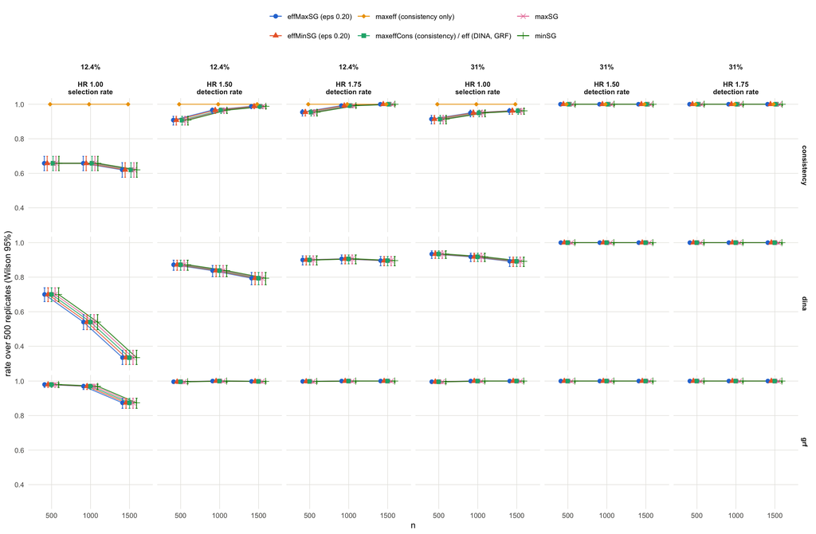

Figure 1: Rate over 500 replicates against n, with Wilson 95% intervals, by engine (rows), prevalence and HR (columns), and criterion (colour and shape). It is a detection rate at HR 1.50 and 1.75, and a selection rate at HR 1.00, where the planted region is differentially null against a benefiting complement and clears the sub-null log(0.90) floor. On DINA and GRF, eff stands for eff = maxeff = maxeffCons.

Table 1: Rate [Wilson 95%] (detected count of 500) by engine, criterion, prevalence and HR, against n. It is a detection rate at HR 1.50 / 1.75 and a selection rate at HR 1.00. On DINA and GRF, eff stands for eff = maxeff = maxeffCons. ‘not run’ marks a deferred cell.

|  | Engine | sg_focus | Prevalence | HR | n 500 | n 1000 | n 1500 |
| --- | --- | --- | --- | --- | --- | --- | --- |
| 193 | consistency | effMaxSG | 12.4% | 1.00 | 0.658 [0.615, 0.698] (329) | 0.658 [0.615, 0.698] (329) | 0.620 [0.577, 0.661] (310) |
| 1 | consistency | effMaxSG | 12.4% | 1.50 | 0.908 [0.879, 0.930] (454) | 0.966 [0.946, 0.979] (483) | 0.988 [0.974, 0.994] (494) |
| 97 | consistency | effMaxSG | 12.4% | 1.75 | 0.954 [0.932, 0.969] (477) | 0.992 [0.980, 0.997] (496) | 1.000 [0.992, 1.000] (500) |
| 241 | consistency | effMaxSG | 31% | 1.00 | 0.914 [0.886, 0.936] (457) | 0.950 [0.927, 0.966] (475) | 0.962 [0.941, 0.976] (481) |
| 49 | consistency | effMaxSG | 31% | 1.50 | 1.000 [0.992, 1.000] (500) | 1.000 [0.992, 1.000] (500) | 1.000 [0.992, 1.000] (500) |
| 145 | consistency | effMaxSG | 31% | 1.75 | 1.000 [0.992, 1.000] (500) | 1.000 [0.992, 1.000] (500) | 1.000 [0.992, 1.000] (500) |
| 194 | consistency | effMinSG | 12.4% | 1.00 | 0.658 [0.615, 0.698] (329) | 0.658 [0.615, 0.698] (329) | 0.620 [0.577, 0.661] (310) |
| 2 | consistency | effMinSG | 12.4% | 1.50 | 0.908 [0.879, 0.930] (454) | 0.966 [0.946, 0.979] (483) | 0.988 [0.974, 0.994] (494) |
| 98 | consistency | effMinSG | 12.4% | 1.75 | 0.954 [0.932, 0.969] (477) | 0.992 [0.980, 0.997] (496) | 1.000 [0.992, 1.000] (500) |
| 242 | consistency | effMinSG | 31% | 1.00 | 0.914 [0.886, 0.936] (457) | 0.950 [0.927, 0.966] (475) | 0.962 [0.941, 0.976] (481) |
| 50 | consistency | effMinSG | 31% | 1.50 | 1.000 [0.992, 1.000] (500) | 1.000 [0.992, 1.000] (500) | 1.000 [0.992, 1.000] (500) |
| 146 | consistency | effMinSG | 31% | 1.75 | 1.000 [0.992, 1.000] (500) | 1.000 [0.992, 1.000] (500) | 1.000 [0.992, 1.000] (500) |
| 195 | consistency | maxeffCons | 12.4% | 1.00 | 0.658 [0.615, 0.698] (329) | 0.658 [0.615, 0.698] (329) | 0.620 [0.577, 0.661] (310) |
| 3 | consistency | maxeffCons | 12.4% | 1.50 | 0.908 [0.879, 0.930] (454) | 0.966 [0.946, 0.979] (483) | 0.988 [0.974, 0.994] (494) |
| 99 | consistency | maxeffCons | 12.4% | 1.75 | 0.954 [0.932, 0.969] (477) | 0.992 [0.980, 0.997] (496) | 1.000 [0.992, 1.000] (500) |
| 243 | consistency | maxeffCons | 31% | 1.00 | 0.914 [0.886, 0.936] (457) | 0.950 [0.927, 0.966] (475) | 0.962 [0.941, 0.976] (481) |
| 51 | consistency | maxeffCons | 31% | 1.50 | 1.000 [0.992, 1.000] (500) | 1.000 [0.992, 1.000] (500) | 1.000 [0.992, 1.000] (500) |
| 147 | consistency | maxeffCons | 31% | 1.75 | 1.000 [0.992, 1.000] (500) | 1.000 [0.992, 1.000] (500) | 1.000 [0.992, 1.000] (500) |
| 196 | consistency | maxeff | 12.4% | 1.00 | 1.000 [0.992, 1.000] (500) | 1.000 [0.992, 1.000] (500) | 1.000 [0.992, 1.000] (500) |
| 4 | consistency | maxeff | 12.4% | 1.50 | 1.000 [0.992, 1.000] (500) | 1.000 [0.992, 1.000] (500) | 1.000 [0.992, 1.000] (500) |
| 100 | consistency | maxeff | 12.4% | 1.75 | 1.000 [0.992, 1.000] (500) | 1.000 [0.992, 1.000] (500) | 1.000 [0.992, 1.000] (500) |
| 244 | consistency | maxeff | 31% | 1.00 | 1.000 [0.992, 1.000] (500) | 1.000 [0.992, 1.000] (500) | 1.000 [0.992, 1.000] (500) |
| 52 | consistency | maxeff | 31% | 1.50 | 1.000 [0.992, 1.000] (500) | 1.000 [0.992, 1.000] (500) | 1.000 [0.992, 1.000] (500) |
| 148 | consistency | maxeff | 31% | 1.75 | 1.000 [0.992, 1.000] (500) | 1.000 [0.992, 1.000] (500) | 1.000 [0.992, 1.000] (500) |
| 197 | consistency | maxSG | 12.4% | 1.00 | 0.658 [0.615, 0.698] (329) | 0.658 [0.615, 0.698] (329) | 0.620 [0.577, 0.661] (310) |
| 5 | consistency | maxSG | 12.4% | 1.50 | 0.908 [0.879, 0.930] (454) | 0.966 [0.946, 0.979] (483) | 0.988 [0.974, 0.994] (494) |
| 101 | consistency | maxSG | 12.4% | 1.75 | 0.954 [0.932, 0.969] (477) | 0.992 [0.980, 0.997] (496) | 1.000 [0.992, 1.000] (500) |
| 245 | consistency | maxSG | 31% | 1.00 | 0.914 [0.886, 0.936] (457) | 0.950 [0.927, 0.966] (475) | 0.962 [0.941, 0.976] (481) |
| 53 | consistency | maxSG | 31% | 1.50 | 1.000 [0.992, 1.000] (500) | 1.000 [0.992, 1.000] (500) | 1.000 [0.992, 1.000] (500) |
| 149 | consistency | maxSG | 31% | 1.75 | 1.000 [0.992, 1.000] (500) | 1.000 [0.992, 1.000] (500) | 1.000 [0.992, 1.000] (500) |

[output cut: 66 more lines]

## 4.2 Subgroup size: mean |Ĥ| / mean |H| against n

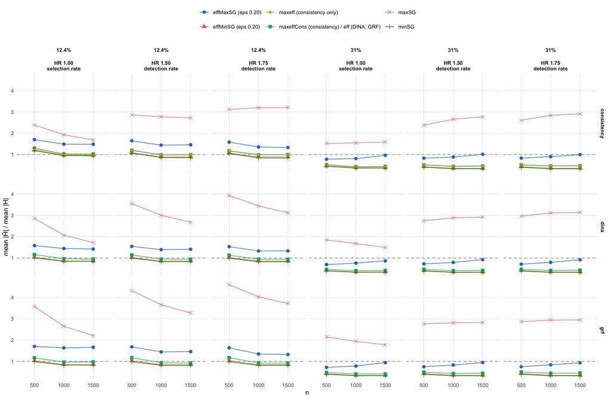

Figure 2: Ratio of mean selected size to mean planted size (both over detected replicates) against n, by engine, prevalence and HR, and criterion. The dashed line marks 1 (the selected subgroup’s mean size equals the planted region’s). On DINA and GRF, eff stands for eff = maxeff = maxeffCons.

Table 2: Mean |Ĥ| / mean |H| (mean |Ĥ| / mean |H|), over detected replicates, against n. A ratio of two means, not a rate, so no interval. On DINA and GRF, eff stands for eff = maxeff = maxeffCons.

|  | Engine | sg_focus | Prevalence | HR | n 500 | n 1000 | n 1500 |
| --- | --- | --- | --- | --- | --- | --- | --- |
| 193 | consistency | effMaxSG | 12.4% | 1.00 | 1.70 (105 / 62) | 1.49 (184 / 124) | 1.48 (276 / 186) |
| 1 | consistency | effMaxSG | 12.4% | 1.50 | 1.65 (102 / 62) | 1.44 (179 / 124) | 1.46 (272 / 186) |
| 97 | consistency | effMaxSG | 12.4% | 1.75 | 1.58 (98 / 62) | 1.35 (168 / 124) | 1.33 (247 / 186) |
| 241 | consistency | effMaxSG | 31% | 1.00 | 0.78 (120 / 154) | 0.81 (249 / 307) | 0.97 (445 / 460) |
| 49 | consistency | effMaxSG | 31% | 1.50 | 0.83 (127 / 154) | 0.89 (272 / 307) | 1.01 (466 / 460) |
| 145 | consistency | effMaxSG | 31% | 1.75 | 0.84 (128 / 154) | 0.90 (277 / 307) | 1.00 (459 / 460) |
| 194 | consistency | effMinSG | 12.4% | 1.00 | 1.20 (74 / 62) | 0.96 (119 / 124) | 0.95 (176 / 186) |
| 2 | consistency | effMinSG | 12.4% | 1.50 | 1.09 (67 / 62) | 0.88 (109 / 124) | 0.88 (164 / 186) |
| 98 | consistency | effMinSG | 12.4% | 1.75 | 1.07 (66 / 62) | 0.89 (110 / 124) | 0.88 (164 / 186) |
| 242 | consistency | effMinSG | 31% | 1.00 | 0.46 (70 / 154) | 0.37 (114 / 307) | 0.37 (172 / 460) |
| 50 | consistency | effMinSG | 31% | 1.50 | 0.43 (66 / 154) | 0.35 (109 / 307) | 0.35 (160 / 460) |
| 146 | consistency | effMinSG | 31% | 1.75 | 0.43 (66 / 154) | 0.36 (109 / 307) | 0.35 (162 / 460) |
| 195 | consistency | maxeffCons | 12.4% | 1.00 | 1.30 (80 / 62) | 1.03 (128 / 124) | 1.02 (191 / 186) |
| 3 | consistency | maxeffCons | 12.4% | 1.50 | 1.20 (74 / 62) | 0.99 (123 / 124) | 1.00 (185 / 186) |
| 99 | consistency | maxeffCons | 12.4% | 1.75 | 1.17 (73 / 62) | 0.99 (123 / 124) | 1.00 (186 / 186) |
| 243 | consistency | maxeffCons | 31% | 1.00 | 0.52 (80 / 154) | 0.43 (131 / 307) | 0.44 (203 / 460) |
| 51 | consistency | maxeffCons | 31% | 1.50 | 0.52 (80 / 154) | 0.45 (138 / 307) | 0.47 (214 / 460) |
| 147 | consistency | maxeffCons | 31% | 1.75 | 0.51 (79 / 154) | 0.47 (144 / 307) | 0.48 (220 / 460) |
| 196 | consistency | maxeff | 12.4% | 1.00 | 1.25 (77 / 62) | 1.00 (123 / 124) | 0.98 (182 / 186) |
| 4 | consistency | maxeff | 12.4% | 1.50 | 1.19 (73 / 62) | 0.99 (122 / 124) | 0.99 (185 / 186) |
| 100 | consistency | maxeff | 12.4% | 1.75 | 1.17 (72 / 62) | 0.99 (123 / 124) | 1.00 (186 / 186) |
| 244 | consistency | maxeff | 31% | 1.00 | 0.51 (78 / 154) | 0.42 (128 / 307) | 0.43 (197 / 460) |
| 52 | consistency | maxeff | 31% | 1.50 | 0.52 (79 / 154) | 0.45 (137 / 307) | 0.47 (214 / 460) |
| 148 | consistency | maxeff | 31% | 1.75 | 0.51 (79 / 154) | 0.47 (144 / 307) | 0.48 (220 / 460) |
| 197 | consistency | maxSG | 12.4% | 1.00 | 2.39 (147 / 62) | 1.93 (239 / 124) | 1.68 (313 / 186) |
| 5 | consistency | maxSG | 12.4% | 1.50 | 2.86 (177 / 62) | 2.78 (344 / 124) | 2.72 (506 / 186) |
| 101 | consistency | maxSG | 12.4% | 1.75 | 3.12 (193 / 62) | 3.20 (396 / 124) | 3.21 (596 / 186) |
| 245 | consistency | maxSG | 31% | 1.00 | 1.52 (234 / 154) | 1.55 (476 / 307) | 1.58 (728 / 460) |
| 53 | consistency | maxSG | 31% | 1.50 | 2.38 (365 / 154) | 2.66 (816 / 307) | 2.77 (1274 / 460) |
| 149 | consistency | maxSG | 31% | 1.75 | 2.61 (401 / 154) | 2.84 (872 / 307) | 2.91 (1340 / 460) |

[output cut: 66 more lines]

## 4.3 Classification: sensitivity, specificity, PPV and NPV against n

Table 3: Sensitivity / specificity / PPV / NPV against the planted region, as replicate means over detected replicates, against n. These are means of per-replicate subject-level proportions, not rates over replicates, so they carry no Wilson interval; the rate each is conditional on is in the rate table. At HR 1.00 the planted region is differentially null against a benefiting complement; the four rates describe how the selection overlaps that region, and nothing more. On DINA and GRF, eff stands for eff = maxeff = maxeffCons.

|  | Engine | sg_focus | Prevalence | HR | n 500 | n 1000 | n 1500 |
| --- | --- | --- | --- | --- | --- | --- | --- |
| 193 | consistency | effMaxSG | 12.4% | 1.00 | 0.430 / 0.821 / 0.280 / 0.910 | 0.505 / 0.862 / 0.359 / 0.926 | 0.617 / 0.878 / 0.450 / 0.942 |
| 1 | consistency | effMaxSG | 12.4% | 1.50 | 0.618 / 0.856 / 0.417 / 0.940 | 0.775 / 0.906 / 0.576 / 0.966 | 0.882 / 0.918 / 0.643 / 0.982 |
| 97 | consistency | effMaxSG | 12.4% | 1.75 | 0.676 / 0.873 / 0.474 / 0.950 | 0.839 / 0.927 / 0.659 / 0.976 | 0.925 / 0.943 / 0.728 / 0.989 |
| 241 | consistency | effMaxSG | 31% | 1.00 | 0.396 / 0.829 / 0.503 / 0.759 | 0.468 / 0.848 / 0.565 / 0.789 | 0.590 / 0.834 / 0.611 / 0.830 |
| 49 | consistency | effMaxSG | 31% | 1.50 | 0.584 / 0.891 / 0.704 / 0.834 | 0.720 / 0.926 / 0.807 / 0.890 | 0.841 / 0.924 / 0.834 / 0.937 |
| 145 | consistency | effMaxSG | 31% | 1.75 | 0.654 / 0.919 / 0.781 / 0.863 | 0.778 / 0.945 / 0.859 / 0.914 | 0.876 / 0.946 / 0.885 / 0.951 |
| 194 | consistency | effMinSG | 12.4% | 1.00 | 0.361 / 0.882 / 0.321 / 0.907 | 0.401 / 0.921 / 0.430 / 0.916 | 0.522 / 0.940 / 0.562 / 0.933 |
| 2 | consistency | effMinSG | 12.4% | 1.50 | 0.571 / 0.928 / 0.538 / 0.939 | 0.555 / 0.953 / 0.626 / 0.938 | 0.621 / 0.963 / 0.700 / 0.947 |
| 98 | consistency | effMinSG | 12.4% | 1.75 | 0.631 / 0.938 / 0.599 / 0.948 | 0.623 / 0.963 / 0.697 / 0.948 | 0.662 / 0.969 / 0.743 / 0.953 |
| 242 | consistency | effMinSG | 31% | 1.00 | 0.226 / 0.898 / 0.495 / 0.724 | 0.199 / 0.923 / 0.531 / 0.722 | 0.223 / 0.933 / 0.594 / 0.731 |
| 50 | consistency | effMinSG | 31% | 1.50 | 0.285 / 0.935 / 0.659 / 0.747 | 0.254 / 0.956 / 0.713 / 0.743 | 0.262 / 0.962 / 0.748 / 0.746 |
| 146 | consistency | effMinSG | 31% | 1.75 | 0.310 / 0.947 / 0.719 / 0.756 | 0.273 / 0.963 / 0.763 / 0.749 | 0.280 / 0.968 / 0.794 / 0.752 |
| 195 | consistency | maxeffCons | 12.4% | 1.00 | 0.362 / 0.868 / 0.302 / 0.906 | 0.437 / 0.916 / 0.432 / 0.920 | 0.555 / 0.933 / 0.555 / 0.937 |
| 3 | consistency | maxeffCons | 12.4% | 1.50 | 0.572 / 0.912 / 0.503 / 0.938 | 0.692 / 0.958 / 0.701 / 0.957 | 0.817 / 0.975 / 0.818 / 0.974 |
| 99 | consistency | maxeffCons | 12.4% | 1.75 | 0.655 / 0.928 / 0.581 / 0.950 | 0.779 / 0.970 / 0.783 / 0.969 | 0.876 / 0.982 / 0.869 / 0.983 |
| 243 | consistency | maxeffCons | 31% | 1.00 | 0.252 / 0.880 / 0.486 / 0.727 | 0.233 / 0.914 / 0.539 / 0.730 | 0.277 / 0.927 / 0.615 / 0.744 |
| 51 | consistency | maxeffCons | 31% | 1.50 | 0.357 / 0.928 / 0.685 / 0.766 | 0.348 / 0.956 / 0.754 / 0.770 | 0.395 / 0.969 / 0.831 / 0.786 |
| 147 | consistency | maxeffCons | 31% | 1.75 | 0.387 / 0.944 / 0.749 / 0.777 | 0.395 / 0.967 / 0.819 / 0.785 | 0.426 / 0.977 / 0.872 / 0.796 |
| 196 | consistency | maxeff | 12.4% | 1.00 | 0.316 / 0.869 / 0.268 / 0.900 | 0.351 / 0.909 / 0.355 / 0.908 | 0.458 / 0.926 / 0.467 / 0.924 |
| 4 | consistency | maxeff | 12.4% | 1.50 | 0.541 / 0.909 / 0.476 / 0.934 | 0.670 / 0.956 / 0.680 / 0.954 | 0.814 / 0.975 / 0.816 / 0.974 |
| 100 | consistency | maxeff | 12.4% | 1.75 | 0.646 / 0.928 / 0.571 / 0.950 | 0.771 / 0.969 / 0.775 / 0.968 | 0.874 / 0.982 / 0.868 / 0.982 |
| 244 | consistency | maxeff | 31% | 1.00 | 0.240 / 0.881 / 0.475 / 0.724 | 0.223 / 0.914 / 0.526 / 0.727 | 0.260 / 0.926 / 0.597 / 0.740 |
| 52 | consistency | maxeff | 31% | 1.50 | 0.356 / 0.929 / 0.686 / 0.766 | 0.347 / 0.955 / 0.752 / 0.769 | 0.395 / 0.969 / 0.831 / 0.786 |
| 148 | consistency | maxeff | 31% | 1.75 | 0.386 / 0.943 / 0.748 / 0.777 | 0.395 / 0.967 / 0.819 / 0.785 | 0.426 / 0.977 / 0.872 / 0.796 |
| 197 | consistency | maxSG | 12.4% | 1.00 | 0.519 / 0.738 / 0.247 / 0.915 | 0.572 / 0.808 / 0.331 / 0.932 | 0.660 / 0.855 / 0.437 / 0.948 |
| 5 | consistency | maxSG | 12.4% | 1.50 | 0.742 / 0.702 / 0.303 / 0.953 | 0.856 / 0.729 / 0.353 / 0.974 | 0.921 / 0.745 / 0.381 / 0.986 |
| 101 | consistency | maxSG | 12.4% | 1.75 | 0.786 / 0.671 / 0.293 / 0.958 | 0.898 / 0.675 / 0.320 / 0.980 | 0.945 / 0.680 / 0.326 / 0.989 |
| 245 | consistency | maxSG | 31% | 1.00 | 0.648 / 0.613 / 0.458 / 0.811 | 0.702 / 0.625 / 0.482 / 0.840 | 0.777 / 0.644 / 0.531 / 0.873 |
| 53 | consistency | maxSG | 31% | 1.50 | 0.914 / 0.351 / 0.407 / 0.913 | 0.966 / 0.250 / 0.372 / 0.958 | 0.979 / 0.207 / 0.358 / 0.968 |
| 149 | consistency | maxSG | 31% | 1.75 | 0.950 / 0.263 / 0.375 / 0.935 | 0.984 / 0.177 / 0.349 / 0.978 | 0.994 / 0.151 / 0.342 / 0.989 |

[output cut: 66 more lines]

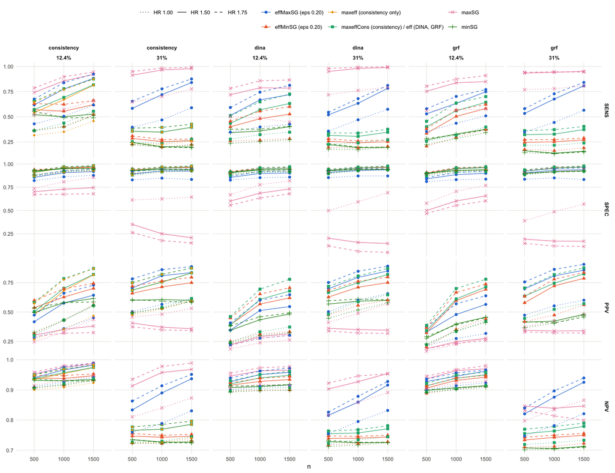

Figure 3: Sensitivity, specificity, PPV and NPV (rows) against n by engine and prevalence (columns), and criterion (colour and shape); HR by line type. Replicate means over detected replicates. On DINA and GRF, eff stands for eff = maxeff = maxeffCons.

## 4.4 Criterion agreement: the same subgroup on the same trial

For each engine and cell, and each pair of that engine’s criteria: of the replicates on which **both** criteria detected, the share on which they selected the **identical** rule (`sg_def` string match). Comparisons are within engine only, because rule strings are engine-specific. The shares carry Wilson intervals over the jointly detected replicates.

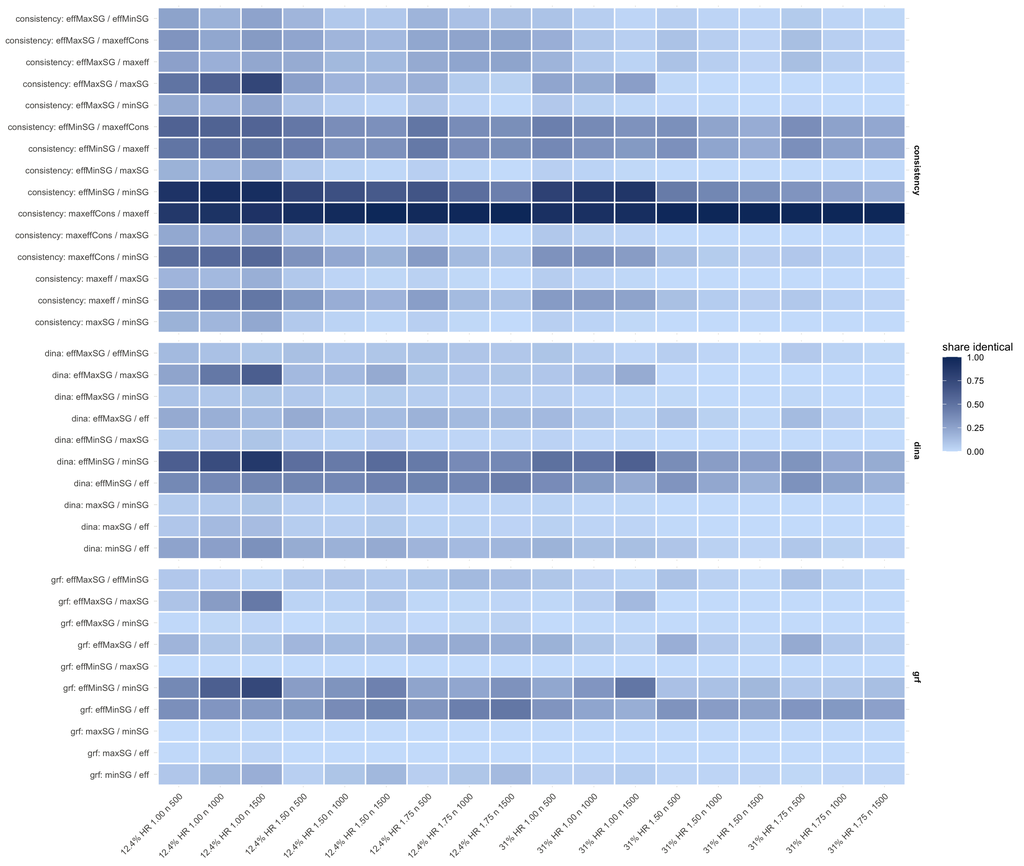

Figure 4: Share of jointly detected replicates on which each pair of criteria selected the identical rule, per engine (panels), criterion pair (rows) and cell (columns; ordered by prevalence, HR, n). Light is 0, dark is 1. On DINA and GRF, eff stands for eff = maxeff = maxeffCons. Counts and Wilson intervals are in the table below.

Table 4: Identical rule on k of m jointly detected replicates, with the share and its Wilson 95% interval, by engine, criterion pair, prevalence and HR, against n. Within engine only. On DINA and GRF, eff stands for eff = maxeff = maxeffCons.

| Engine | Criterion pair | Prevalence | HR | n 500 | n 1000 | n 1500 |
| --- | --- | --- | --- | --- | --- | --- |
| consistency | effMaxSG / effMinSG | 12.4% | 1.00 | 83/329 0.252 [0.208, 0.302] | 59/329 0.179 [0.142, 0.224] | 77/310 0.248 [0.204, 0.299] |
| consistency | effMaxSG / effMinSG | 12.4% | 1.50 | 74/454 0.163 [0.132, 0.200] | 39/483 0.081 [0.060, 0.108] | 39/494 0.079 [0.058, 0.106] |
| consistency | effMaxSG / effMinSG | 12.4% | 1.75 | 82/477 0.172 [0.141, 0.208] | 57/496 0.115 [0.090, 0.146] | 60/500 0.120 [0.094, 0.151] |
| consistency | effMaxSG / effMinSG | 31% | 1.00 | 46/457 0.101 [0.076, 0.132] | 25/475 0.053 [0.036, 0.077] | 11/481 0.023 [0.013, 0.040] |
| consistency | effMaxSG / effMinSG | 31% | 1.50 | 27/500 0.054 [0.037, 0.077] | 13/500 0.026 [0.015, 0.044] | 10/500 0.020 [0.011, 0.036] |
| consistency | effMaxSG / effMinSG | 31% | 1.75 | 35/500 0.070 [0.051, 0.096] | 13/500 0.026 [0.015, 0.044] | 9/500 0.018 [0.009, 0.034] |
| consistency | effMaxSG / maxeffCons | 12.4% | 1.00 | 106/329 0.322 [0.274, 0.374] | 76/329 0.231 [0.189, 0.279] | 90/310 0.290 [0.243, 0.343] |
| consistency | effMaxSG / maxeffCons | 12.4% | 1.50 | 108/454 0.238 [0.201, 0.279] | 79/483 0.164 [0.133, 0.199] | 72/494 0.146 [0.117, 0.180] |
| consistency | effMaxSG / maxeffCons | 12.4% | 1.75 | 110/477 0.231 [0.195, 0.270] | 121/496 0.244 [0.208, 0.284] | 124/500 0.248 [0.212, 0.288] |
| consistency | effMaxSG / maxeffCons | 31% | 1.00 | 89/457 0.195 [0.161, 0.234] | 41/475 0.086 [0.064, 0.115] | 22/481 0.046 [0.030, 0.068] |
| consistency | effMaxSG / maxeffCons | 31% | 1.50 | 54/500 0.108 [0.084, 0.138] | 26/500 0.052 [0.036, 0.075] | 12/500 0.024 [0.014, 0.041] |
| consistency | effMaxSG / maxeffCons | 31% | 1.75 | 62/500 0.124 [0.098, 0.156] | 24/500 0.048 [0.032, 0.070] | 12/500 0.024 [0.014, 0.041] |
| consistency | effMaxSG / maxeff | 12.4% | 1.00 | 86/329 0.261 [0.217, 0.311] | 62/329 0.188 [0.150, 0.234] | 71/310 0.229 [0.186, 0.279] |
| consistency | effMaxSG / maxeff | 12.4% | 1.50 | 96/454 0.211 [0.176, 0.251] | 72/483 0.149 [0.120, 0.184] | 71/494 0.144 [0.116, 0.177] |
| consistency | effMaxSG / maxeff | 12.4% | 1.75 | 104/477 0.218 [0.183, 0.257] | 120/496 0.242 [0.206, 0.282] | 124/500 0.248 [0.212, 0.288] |
| consistency | effMaxSG / maxeff | 31% | 1.00 | 78/457 0.171 [0.139, 0.208] | 35/475 0.074 [0.053, 0.101] | 16/481 0.033 [0.021, 0.053] |
| consistency | effMaxSG / maxeff | 31% | 1.50 | 54/500 0.108 [0.084, 0.138] | 26/500 0.052 [0.036, 0.075] | 12/500 0.024 [0.014, 0.041] |
| consistency | effMaxSG / maxeff | 31% | 1.75 | 62/500 0.124 [0.098, 0.156] | 24/500 0.048 [0.032, 0.070] | 12/500 0.024 [0.014, 0.041] |
| consistency | effMaxSG / maxSG | 12.4% | 1.00 | 162/329 0.492 [0.439, 0.546] | 196/329 0.596 [0.542, 0.647] | 237/310 0.765 [0.714, 0.808] |
| consistency | effMaxSG / maxSG | 12.4% | 1.50 | 122/454 0.269 [0.230, 0.311] | 81/483 0.168 [0.137, 0.204] | 78/494 0.158 [0.128, 0.193] |
| consistency | effMaxSG / maxSG | 12.4% | 1.75 | 90/477 0.189 [0.156, 0.226] | 34/496 0.069 [0.049, 0.094] | 22/500 0.044 [0.029, 0.066] |
| consistency | effMaxSG / maxSG | 31% | 1.00 | 110/457 0.241 [0.204, 0.282] | 102/475 0.215 [0.180, 0.254] | 130/481 0.270 [0.233, 0.312] |
| consistency | effMaxSG / maxSG | 31% | 1.50 | 7/500 0.014 [0.007, 0.029] | 1/500 0.002 [0.000, 0.011] | 0/500 0.000 [0.000, 0.008] |
| consistency | effMaxSG / maxSG | 31% | 1.75 | 0/500 0.000 [0.000, 0.008] | 0/500 0.000 [0.000, 0.008] | 0/500 0.000 [0.000, 0.008] |
| consistency | effMaxSG / minSG | 12.4% | 1.00 | 71/329 0.216 [0.175, 0.263] | 57/329 0.173 [0.136, 0.218] | 74/310 0.239 [0.195, 0.289] |
| consistency | effMaxSG / minSG | 12.4% | 1.50 | 45/454 0.099 [0.075, 0.130] | 23/483 0.048 [0.032, 0.070] | 11/494 0.022 [0.012, 0.039] |
| consistency | effMaxSG / minSG | 12.4% | 1.75 | 44/477 0.092 [0.069, 0.122] | 14/496 0.028 [0.017, 0.047] | 3/500 0.006 [0.002, 0.017] |
| consistency | effMaxSG / minSG | 31% | 1.00 | 35/457 0.077 [0.056, 0.105] | 20/475 0.042 [0.027, 0.064] | 7/481 0.015 [0.007, 0.030] |
| consistency | effMaxSG / minSG | 31% | 1.50 | 4/500 0.008 [0.003, 0.020] | 3/500 0.006 [0.002, 0.017] | 0/500 0.000 [0.000, 0.008] |
| consistency | effMaxSG / minSG | 31% | 1.75 | 4/500 0.008 [0.003, 0.020] | 1/500 0.002 [0.000, 0.011] | 0/500 0.000 [0.000, 0.008] |

[output cut: 180 more lines]

# 5 Provenance

- **Bundles:** `results/*_nomr_idsweep_res_1_500.rds`. There is one batch per run: 500 replicates did not need splitting, so there is no combine render. Each run’s batch render is `idsweep_<cell>_<engine>_<criterion>.html`.
- **Driver and gates:** `scripts_dinamr/idsweep.sh`, with Gate A per run (`idsweep_gateA.R`), Gate I per cell (`idsweep_gateI.R`) and Gate 1 (`idsweep_project.R`). Logs are in `scripts_dinamr/logs/idsweep*`.
- **Findings and walls:** `REPORT_idsweep_2026-09-12.md`.

```
Rendered 2026-09-13 12:01:38; forestsearch 0.3.5; R version 4.5.2 (2025-10-31); 288 bundles read.
```